# Schweizer Ratsstatistiken

Diese Minichallenge basiert auf demselben Datenset mit ähnlichen Fragestellungen wie die Minichallenge (Abgabe 2) im Modul DDI (Datenbankdesign und Implementierung).

## Ausgangslage

Du machst ein Praktikum beim Bundesamt für Statistik. Dieses möchte gerne neu auf seiner Webseite eine Sektion mit interessanten historischen Fakten zu den Räten der Exekutive und Legislative (Bundes- National- und Ständerat) anbieten. Dazu wird dir ein Datenset in Form einer Excel-Datei zur Verfügung gestellt.

## Datenimport

```python
import pandas as pd
import matplotlib.pyplot as plt
import seaborn as sns
```

```python
# Excel-Datei in ein Dataframe einlesen
filename = "Ratsmitglieder.xlsx"
df = pd.read_excel(filename)
df.head()
```

|  | Active | FirstName | LastName | GenderAsString | CantonName | CantonAbbreviation | CouncilName | ParlGroupName | ParlGroupAbbreviation | PartyName | PartyAbbreviation | MaritalStatusText | BirthPlace_City | BirthPlace_Canton | Mandates | DateJoining | DateLeaving | Citizenship | DateOfBirth | DateOfDeath |
| --- | --- | --- | --- | --- | --- | --- | --- | --- | --- | --- | --- | --- | --- | --- | --- | --- | --- | --- | --- | --- |
| 0 | False | Giuseppe | a Marca | m | Graubünden | GR | Ständerat | Mitte | MC | Konservative | Kons* | NaN | NaN | NaN | NaN | 01.12.1849 | 01.07.1851 | Soazza (GR) | 29.07.1799 | 16.07.1866 |
| 1 | False | Alois | Ab Yberg | m | Schwyz | SZ | Nationalrat | Radikal-demokratische Fraktion | R | Freisinnig-Demokratische Partei der Schweiz | FDP | NaN | NaN | NaN | NaN | 03.12.1928 | 01.12.1935 | Schwyz (SZ) | 06.10.1878 | 17.10.1959 |
| 2 | False | Fabio | Abate | m | Tessin | TI | Nationalrat | Freisinnig-demokratische Fraktion | RL | Freisinnig-Demokratische Partei der Schweiz | FDP | NaN | Locarno | Tessin | incarichi esecutivi presso il comune di Locarn... | 03.12.2007 | 04.12.2011 | Cabbio (TI) | 04.01.1966 | NaN |
| 3 | False | Fabio | Abate | m | Tessin | TI | Nationalrat | Freisinnig-demokratische Fraktion | R | Freisinnig-Demokratische Partei der Schweiz | FDP | NaN | Locarno | Tessin | incarichi esecutivi presso il comune di Locarn... | 25.09.2000 | 30.11.2003 | Cabbio (TI) | 04.01.1966 | NaN |
| 4 | False | Fabio | Abate | m | Tessin | TI | Ständerat | FDP-Liberale Fraktion | RL | FDP.Die Liberalen | FDP-Liberale | NaN | Locarno | Tessin | incarichi esecutivi presso il comune di Locarn... | 05.12.2011 | 29.11.2015 | Cabbio (TI) | 04.01.1966 | NaN |

```python
df.tail()
```

|  | Active | FirstName | LastName | GenderAsString | CantonName | CantonAbbreviation | CouncilName | ParlGroupName | ParlGroupAbbreviation | PartyName | PartyAbbreviation | MaritalStatusText | BirthPlace_City | BirthPlace_Canton | Mandates | DateJoining | DateLeaving | Citizenship | DateOfBirth | DateOfDeath |
| --- | --- | --- | --- | --- | --- | --- | --- | --- | --- | --- | --- | --- | --- | --- | --- | --- | --- | --- | --- | --- |
| 6425 | False | Otto (senior) | Zwygart | m | Bern | BE | Nationalrat | Demokratische und Evangelische Fraktion | DE | Evangelische Volkspartei der Schweiz | EVP | NaN | NaN | NaN | NaN | 01.06.1971 | 27.11.1983 | Meikirch (BE) | 30.05.1911 | 05.04.1986 |
| 6426 | False | Otto | Zwygart | m | Bern | BE | Nationalrat | LdU/EVP-Fraktion | U | Evangelische Volkspartei der Schweiz | EVP | NaN | Schliern | Bern | Grosser Gemeinderat Bolligen von 1970 bis 1974... | 28.11.1983 | 03.12.1995 | Bolligen (BE),Meikirch (BE) | 16.01.1940 | NaN |
| 6427 | False | Carl Sam. | Zyro | m | Bern | BE | Nationalrat | Linke | LG | Freisinnig-Demokratische Partei der Schweiz | FDP | NaN | NaN | NaN | NaN | 03.12.1866 | 03.12.1893 | Thun (BE) | 17.07.1834 | 26.08.1896 |
| 6428 | False | Carl Sam. | Zyro | m | Bern | BE | Nationalrat | Linke | LG | Freisinnig-Demokratische Partei der Schweiz | FDP | NaN | NaN | NaN | NaN | 03.12.1866 | 03.12.1893 | Thun (BE) | 17.07.1834 | 26.08.1896 |
| 6429 | False | Carl Sam. | Zyro | m | Bern | BE | Nationalrat | Linke | LG | Freisinnig-Demokratische Partei der Schweiz | FDP | NaN | NaN | NaN | NaN | 03.12.1866 | 03.12.1893 | Thun (BE) | 17.07.1834 | 26.08.1896 |

```python
df.info()
```

```
<class 'pandas.core.frame.DataFrame'>
RangeIndex: 6430 entries, 0 to 6429
Data columns (total 20 columns):
 #   Column                 Non-Null Count  Dtype
---  ------                 --------------  -----
 0   Active                 6430 non-null   bool
 1   FirstName              6430 non-null   object
 2   LastName               6430 non-null   object
 3   GenderAsString         6430 non-null   object
 4   CantonName             6428 non-null   object
 5   CantonAbbreviation     6428 non-null   object
 6   CouncilName            6425 non-null   object
 7   ParlGroupName          4952 non-null   object
 8   ParlGroupAbbreviation  4952 non-null   object
 9   PartyName              6352 non-null   object
 10  PartyAbbreviation      6350 non-null   object
 11  MaritalStatusText      240 non-null    object
 12  BirthPlace_City        2165 non-null   object
 13  BirthPlace_Canton      2087 non-null   object
 14  Mandates               1882 non-null   object
 15  DateJoining            6430 non-null   object
 16  DateLeaving            6174 non-null   object
 17  Citizenship            6423 non-null   object
 18  DateOfBirth            6430 non-null   object
 19  DateOfDeath            4270 non-null   object
dtypes: bool(1), object(19)
memory usage: 960.9+ KB
```

Bei der Durchsicht der Datentypen fällt auf, dass es nur einen Boolean (Active) und die restlichen 19 Daten als object eingelesen hat. Es sind Datums-Variablen vorhanden, welche ins Datumsformat konvertiert werden müssen. Weiter sind kategoriale Variablen vorhanden, welche für eine Analyse konvertiert werden.

## 2 Aufgabenstellung

### 2.1 Explorative Analyse und Assessment der Datenqualität

#### Konvertierung der Datentypen

In Datumsformate werden folgende Variablen konvertiert:

- DateJoining
- DateLeaving
- DateOfBirth
- DateOfDeath

Kategoriale Variablen sind:

- GenderAsString
- CantonName
- CantonAbbreviation
- CouncilName
- PartyName
- PartyAbbreviation
- BirthPlace_Canton Diese werden erst zu einem späteren Zeitpunkt konvertiert.

```python
# Datumsvariablen konvertieren
columns_to_convert = ['DateJoining', 'DateLeaving', 'DateOfBirth', 'DateOfDeath']
for col in columns_to_convert:
    df[col] = pd.to_datetime(df[col], format= '%d.%m.%Y')

df.info()
```

```
<class 'pandas.core.frame.DataFrame'>
RangeIndex: 6430 entries, 0 to 6429
Data columns (total 20 columns):
 #   Column                 Non-Null Count  Dtype
---  ------                 --------------  -----
 0   Active                 6430 non-null   bool
 1   FirstName              6430 non-null   object
 2   LastName               6430 non-null   object
 3   GenderAsString         6430 non-null   object
 4   CantonName             6428 non-null   object
 5   CantonAbbreviation     6428 non-null   object
 6   CouncilName            6425 non-null   object
 7   ParlGroupName          4952 non-null   object
 8   ParlGroupAbbreviation  4952 non-null   object
 9   PartyName              6352 non-null   object
 10  PartyAbbreviation      6350 non-null   object
 11  MaritalStatusText      240 non-null    object
 12  BirthPlace_City        2165 non-null   object
 13  BirthPlace_Canton      2087 non-null   object
 14  Mandates               1882 non-null   object
 15  DateJoining            6430 non-null   datetime64[ns]
 16  DateLeaving            6174 non-null   datetime64[ns]
 17  Citizenship            6423 non-null   object
 18  DateOfBirth            6430 non-null   datetime64[ns]
 19  DateOfDeath            4270 non-null   datetime64[ns]
dtypes: bool(1), datetime64[ns](4), object(15)
memory usage: 960.9+ KB
```

#### Spalten entfernen

Für die spätere Beantwortung der Fragen sind nicht alle Spalten nötig. Deshalb wird der Datensatz angepasst. Wir erstellen einen neuen Datensatz mit dem Namen df_reduced. Dabei werden folgende Spalten weggelassen:

- MaritalStatusText
- ParlGroupName
- ParlGroupAbbreviation
- Mandates

```python
df_reduced = df.drop(['MaritalStatusText', 'ParlGroupName', 'ParlGroupAbbreviation', 'Mandates'], axis='columns')
df_reduced.head()
```

|  | Active | FirstName | LastName | GenderAsString | CantonName | CantonAbbreviation | CouncilName | PartyName | PartyAbbreviation | BirthPlace_City | BirthPlace_Canton | DateJoining | DateLeaving | Citizenship | DateOfBirth | DateOfDeath |
| --- | --- | --- | --- | --- | --- | --- | --- | --- | --- | --- | --- | --- | --- | --- | --- | --- |
| 0 | False | Giuseppe | a Marca | m | Graubünden | GR | Ständerat | Konservative | Kons* | NaN | NaN | 1849-12-01 | 1851-07-01 | Soazza (GR) | 1799-07-29 | 1866-07-16 |
| 1 | False | Alois | Ab Yberg | m | Schwyz | SZ | Nationalrat | Freisinnig-Demokratische Partei der Schweiz | FDP | NaN | NaN | 1928-12-03 | 1935-12-01 | Schwyz (SZ) | 1878-10-06 | 1959-10-17 |
| 2 | False | Fabio | Abate | m | Tessin | TI | Nationalrat | Freisinnig-Demokratische Partei der Schweiz | FDP | Locarno | Tessin | 2007-12-03 | 2011-12-04 | Cabbio (TI) | 1966-01-04 | NaT |
| 3 | False | Fabio | Abate | m | Tessin | TI | Nationalrat | Freisinnig-Demokratische Partei der Schweiz | FDP | Locarno | Tessin | 2000-09-25 | 2003-11-30 | Cabbio (TI) | 1966-01-04 | NaT |
| 4 | False | Fabio | Abate | m | Tessin | TI | Ständerat | FDP.Die Liberalen | FDP-Liberale | Locarno | Tessin | 2011-12-05 | 2015-11-29 | Cabbio (TI) | 1966-01-04 | NaT |

#### Fehlende Werte

Dazu die erste übersicht über die fehlenden Werte:

```python
df_reduced.isna().sum()
```

```
Active                   0
FirstName                0
LastName                 0
GenderAsString           0
CantonName               2
CantonAbbreviation       2
CouncilName              5
PartyName               78
PartyAbbreviation       80
BirthPlace_City       4265
BirthPlace_Canton     4343
DateJoining              0
DateLeaving            256
Citizenship              7
DateOfBirth              0
DateOfDeath           2160
dtype: int64
```

Bei den Spalten 'CantonName' und 'CantonAbbreviation' fehlen jeweils 2 Werte. Mit der Filterfunktion kann bei einer so kleinen Menge sehr schnell herausgefunden werden, ob es sich um dieselben Observationen handelt, in denen beide Werte fehlen, oder ob es verschiedene Observationen sind. Im zweiten Fall könnten die fehlenden Werte ergänzt werden, indem die Werte aus der anderen Spalte übernommen werden.

```python
df_canton_na = df_reduced[(df_reduced['CantonName'].isna()) | (df_reduced['CantonAbbreviation'].isna())]
df_canton_na
```

|  | Active | FirstName | LastName | GenderAsString | CantonName | CantonAbbreviation | CouncilName | PartyName | PartyAbbreviation | BirthPlace_City | BirthPlace_Canton | DateJoining | DateLeaving | Citizenship | DateOfBirth | DateOfDeath |
| --- | --- | --- | --- | --- | --- | --- | --- | --- | --- | --- | --- | --- | --- | --- | --- | --- |
| 941 | False | Walter | Buser | m | NaN | NaN | NaN | NaN | NaN | Lausen | Basel-Landschaft | 1981-07-01 | 1991-06-30 | NaN | 1926-04-14 | 2019-08-17 |
| 1233 | False | François | Couchepin | m | NaN | NaN | NaN | NaN | NaN | NaN | NaN | 1991-12-04 | 1999-12-14 | NaN | 1935-01-19 | NaT |

Es handelt sich um zwei Observationen. Bei der Durchsicht dieser Observationen fällt sofort auf, dass beide sehr wenige Einträge aufweisen. Zudem sind relevante Informationen zur Ratsmitgliedschaft nicht vorhanden. Diese Observationen sind mit den vorhandenen Informationen für unsere Fragestellungen nicht relevant. Aus diesem Grund werden sie aus dem Datenset entfernt.

```python
df_mod = df_reduced.drop(df_canton_na.index)
df_mod.isna().sum()
```

```
Active                   0
FirstName                0
LastName                 0
GenderAsString           0
CantonName               0
CantonAbbreviation       0
CouncilName              3
PartyName               76
PartyAbbreviation       78
BirthPlace_City       4264
BirthPlace_Canton     4342
DateJoining              0
DateLeaving            256
Citizenship              5
DateOfBirth              0
DateOfDeath           2159
dtype: int64
```

Im nächsten Schritt werden die Einträge der Spalte 'CouncilName' untersucht. Dabei wird nach Hinweisen für die Gründe der fehlenden Werte gesucht.

```python
df_council_na = df_mod[df_mod['CouncilName'].isna()]
df_council_na
```

|  | Active | FirstName | LastName | GenderAsString | CantonName | CantonAbbreviation | CouncilName | PartyName | PartyAbbreviation | BirthPlace_City | BirthPlace_Canton | DateJoining | DateLeaving | Citizenship | DateOfBirth | DateOfDeath |
| --- | --- | --- | --- | --- | --- | --- | --- | --- | --- | --- | --- | --- | --- | --- | --- | --- |
| 1027 | False | Corina | Casanova | f | Graubünden | GR | NaN | Christlichdemokratische Volkspartei der Schweiz | CVP | Ilanz | Graubünden | 2008-01-01 | 2015-12-31 | Ruschein (GR),Vrin (GR) | 1956-01-04 | NaT |
| 2837 | False | Annemarie | Huber-Hotz | f | Bern | BE | NaN | Freisinnig-Demokratische Partei der Schweiz | FDP | Baar | Zug | 1999-12-15 | 2007-12-31 | Kirchberg (SG),Baar (ZG) | 1948-08-16 | 2019-08-01 |
| 5692 | True | Walter | Thurnherr | m | Aargau | AG | NaN | Christlichdemokratische Volkspartei der Schweiz | CVP | Muri | Aargau | 2016-01-01 | NaT | NaN | 1963-07-11 | NaT |

Bei diesen drei Personen handelt es sich offensichtlich um Personen, welche als Bundeskanzler im Amt waren oder sind. Da diese Information gesichert ist, werden die fehlenden Werte mit 'Bundeskanzler' ergänzt.

```python
df_mod['CouncilName'] = df_mod['CouncilName'].fillna('Bundeskanzler')
df_mod.isna().sum()
```

```
Active                   0
FirstName                0
LastName                 0
GenderAsString           0
CantonName               0
CantonAbbreviation       0
CouncilName              0
PartyName               76
PartyAbbreviation       78
BirthPlace_City       4264
BirthPlace_Canton     4342
DateJoining              0
DateLeaving            256
Citizenship              5
DateOfBirth              0
DateOfDeath           2159
dtype: int64
```

Nun werden die Parteinamen genauer angeschaut. Konkret geht es hier wiederum als erstes um die fehlenden Werte. Da der Parteiname und die Partei-Abkürzung zusammenhängen, wird nach vorhandenen Werten in der einen oder anderen Spalte gesucht. Falls solche Observationen vorahnden sind, können die fehlenden Werte ergänzt werden.

```python
df_party_abbr_na = df_mod[df_mod['PartyName'].isna() & df_mod['PartyAbbreviation'].notna() | df_mod['PartyName'].notna() & df_mod['PartyAbbreviation'].isna()]
df_party_abbr_na
```

|  | Active | FirstName | LastName | GenderAsString | CantonName | CantonAbbreviation | CouncilName | PartyName | PartyAbbreviation | BirthPlace_City | BirthPlace_Canton | DateJoining | DateLeaving | Citizenship | DateOfBirth | DateOfDeath |
| --- | --- | --- | --- | --- | --- | --- | --- | --- | --- | --- | --- | --- | --- | --- | --- | --- |
| 2641 | False | Jean-Jacques | Hegg | m | Zürich | ZH | Nationalrat | Nationale Aktion | NaN | NaN | NaN | 1983-11-28 | 1985-02-01 | Dübendorf (ZH) | 1930-11-10 | 2021-03-24 |
| 5449 | False | Hans | Steffen | m | Zürich | ZH | Nationalrat | Nationale Aktion | NaN | Zürich | Zürich | 1985-02-04 | 1995-12-03 | Zürich (ZH),Kloten (ZH),Fischenthal (ZH) | 1931-09-29 | NaT |

#### Fehlende Werte in 'ParyAbbreviation' mit den Werten aus 'PartyName' ergänzen

Die Abkürzung der Partei 'Nationale Aktion' ist NA. Dieser Wert kann bei der Spalte 'PartyAbbreviation' nicht verwendet werden, da er bereits für die fehlenden Werte steht. Aus diesem Grund wird der Parteiname ergänzt.

```python
df_mod.loc[df_mod['PartyAbbreviation'].isna(), 'PartyAbbreviation'] = df_mod['PartyName']
df_mod.isna().sum()
```

```
Active                   0
FirstName                0
LastName                 0
GenderAsString           0
CantonName               0
CantonAbbreviation       0
CouncilName              0
PartyName               76
PartyAbbreviation       76
BirthPlace_City       4264
BirthPlace_Canton     4342
DateJoining              0
DateLeaving            256
Citizenship              5
DateOfBirth              0
DateOfDeath           2159
dtype: int64
```

Nun fehlen die Parteinamen und deren Abkürzungen bei denselben Personen. Die nächste Variable, die genauer angeschaut wird, ist die Spalte 'Citizenship'.

```python
df_citizenship_na = df_mod[df_mod['Citizenship'].isna()]
df_citizenship_na
```

|  | Active | FirstName | LastName | GenderAsString | CantonName | CantonAbbreviation | CouncilName | PartyName | PartyAbbreviation | BirthPlace_City | BirthPlace_Canton | DateJoining | DateLeaving | Citizenship | DateOfBirth | DateOfDeath |
| --- | --- | --- | --- | --- | --- | --- | --- | --- | --- | --- | --- | --- | --- | --- | --- | --- |
| 1007 | False | P. A. Edouard | Carlin | m | Bern | BE | Nationalrat | Freisinnig-Demokratische Partei der Schweiz | FDP | NaN | NaN | 1854-12-04 | 1870-06-21 | NaN | 1817-06-26 | 1870-06-21 |
| 1133 | False | Fr.-Joseph | Choquard | m | Bern | BE | Nationalrat | Konservative | Kons* | NaN | NaN | 1901-03-18 | 1928-12-02 | NaN | 1855-07-22 | 1937-10-24 |
| 1134 | False | Fr.-Joseph | Choquard | m | Bern | BE | Nationalrat | Konservative | Kons* | NaN | NaN | 1890-12-01 | 1895-10-01 | NaN | 1855-07-22 | 1937-10-24 |
| 4435 | True | Léonore | Porchet | f | Waadt | VD | Nationalrat | Grüne Partei der Schweiz | GPS | Châtel-St-Denis | Freiburg | 2019-12-02 | NaT | NaN | 1989-07-09 | NaT |
| 5692 | True | Walter | Thurnherr | m | Aargau | AG | Bundeskanzler | Christlichdemokratische Volkspartei der Schweiz | CVP | Muri | Aargau | 2016-01-01 | NaT | NaN | 1963-07-11 | NaT |

Es können keine Rückschlüsse auf diese fehlenden Werte gemacht werden, weshalb die Observationen so belassen werden. Bei der Spalte 'PartyAbbreviation' gibt es Werte, die am Schluss der Abkürzung ein * aufweisen. Diese Einträge werden genauer untersucht.

```python
df_notna = df_mod[df_mod['PartyAbbreviation'].notna()]
df_party_abbr_star = df_notna[df_notna['PartyAbbreviation'].str.contains('\*', regex=True)]
df_party_abbr_star = df_party_abbr_star[['PartyName', 'PartyAbbreviation']].drop_duplicates()
df_party_abbr_star.head()
```

|  | PartyName | PartyAbbreviation |
| --- | --- | --- |
| 0 | Konservative | Kons* |
| 7 | Liberale | Lib* |
| 24 | Demokraten | Dem* |
| 190 | Gemässigte Konservative | GKons* |
| 321 | Grütlianer | Grüt* |

Es betrifft 1401 Einträge, welche mit Stern versehen sind. Nun interessiert, ob es sich bei allen Abkürzungen zu den jeweiligen Parteinamen so verhält, oder ob gewisse Abkürzungen ohne Stern vorhanden sind. Dazu wird ein Datenset mit allen Parteinamen erstellt, welche auch im Datenset df_party_abbr_star vorhanden sind. Dieses neue Datenset wird nur mit dem Parteinamen und deren Abkürzung erstellt. Die Werte sollen auch nur einmal vorhanden sein.

```python
df_partyname_unique = df_notna[df_notna['PartyName'].isin(df_party_abbr_star['PartyName'])][['PartyName', 'PartyAbbreviation']].drop_duplicates()
df_partyname_unique.head()
```

|  | PartyName | PartyAbbreviation |
| --- | --- | --- |
| 0 | Konservative | Kons* |
| 7 | Liberale | Lib* |
| 24 | Demokraten | Dem* |
| 190 | Gemässigte Konservative | GKons* |
| 321 | Grütlianer | Grüt* |

Es sind auch 32 Reihen vorhanden, wie im Datenset df_party_abbr_star. Eine Durchsicht von Hand (aufgrund der kleinen Datenmenge gut möglich) zeigt auch keine weiteren Auffälligkeiten. Die Abkürzungen mit Stern werden so belassen.

Das Datenset df_mod weist noch Ungereimtheiten bei den Spalten 'BirthPlace_City' und 'BirthPlace_Canton' auf. Diese werden im nächsten Schritt genauer untersucht. Dazu wird zuerst eine Liste mit allen Geburtsorten erstellt.

```python
list_city_of_birth = df_mod['BirthPlace_City'].dropna().unique()
list_city_of_birth
```

```
array(['Locarno', 'Lausanne', 'Burgdorf', 'Schwarzenburg', 'Bern',
       'Winterthur', 'St. Gallen', 'Zug', 'Pompaples', 'Basel',
       'Montevideo', 'Genève', 'Bienne', 'Brig-Glis', 'Altstätten',
       'Schaffhausen', 'Sierre', 'Sigriswil', 'Freiburg', 'Siders',
       'Hasle', 'Altdorf', 'Erzincan', 'Elbistan', 'Le Chenit',
       'Mümliswil', 'Sumiswald', 'Sydney', 'Delémont', 'Aarberg',
       'Bardonnex', 'Neuchâtel', 'Suberg', 'Zürich', 'Wassen',
       'St. Imier', 'Thalwil', 'Genève 8', 'Biel', 'Boudry',
       'La Chaux-de-Fonds', 'Lille', 'Neuenburg', 'Uznach', 'Thun',
       'Scuol', 'Vilters', 'Lugano', 'Viganello', 'Illnau-Effretikon',
       'Wölflinswil', 'Emmen', 'Solothurn', 'Heiden', 'Lachen',
       'Laufen am Rheinfall', 'Stein am Rhein', 'Aigle',
       'Affoltern am Albis', 'Horgen', 'Huttwil', 'Vnà', 'Visp',
       'Binningen', 'Belp', 'Baden', 'Ruswil', 'Wattwil', 'Fribourg',
       'Schänis', 'Yverdon-les-Bains', 'St-Prex', 'Sempach', 'Hofen',
       'Zofingen', 'Frauenfeld', 'Monthey', 'Wolfwil', 'Cadenazzo',
       'Cinuos-chel', 'Ilanz', 'Mendrisio', 'Bellinzona', 'Sessa',
       'Brigels', 'Sorengo', 'Chur', 'Morges', 'Aubonne', 'Sitten',
       'Untersiggenthal', 'Salgesch', 'Saxon', 'Billens', 'Muralto',
       'Jaun', 'Martigny', 'Amsterdam', 'Le Pâquier', 'Andermatt',
       'Savièse', 'Trun', 'St-Léonard', 'Schwyz', 'Einsiedeln',
       'Attinghausen', 'Männedorf', 'Luzern', 'Vevey', 'Alpnach',
       'Küssnacht am Rigi', 'Münsterlingen', 'Rorschach', 'Menziken',
       'Ibach', 'Aarau', 'Appenzell', 'Bratislava', 'Sursee', 'Kerns',
       'La Rippe', 'Comano', 'Alterswil', 'Villars-Bramard', 'Fleurier',
       'Chêne-Bougeries', 'Berg am Irchel', 'Wallisellen', 'Rheinklingen',
       'Genolier', 'Salins', 'Triengen', 'Hägglingen', 'Horw',
       'Unterseen', 'Muotathal', 'Riddes', 'Metz', 'Glarus', 'Wittenbach',
       'Schönenwerd', 'Moutier', 'Erlenbach im Simmental', 'Muri', 'Riaz',
       'Langenthal', 'Herisau', 'Faido', 'Sion', 'Samedan', 'Rothrist',
       'Baar', 'Oftringen', 'Sissach', 'Uster', 'Breslau',
       'Valeyres-sous-Rances', 'New York', 'Flawil', 'Kobe', 'Frutigen',
       'Kapstadt', 'Rüderswil', 'Porrentruy', 'Udupi', 'Uzwil',
       'Wädenswil', 'Mettmenstetten', 'Wetzikon (ZH)', 'Grenchen',
       'Montreal', 'Merishausen', 'Pratval', 'Donat', 'Ottenbach',
       'Edlibach', 'Neuendorf', 'Budapest', 'Unterägeri', 'Roggwil',
       'Niederuzwil', 'Dürrenroth', 'Degersheim', 'Niedergösgen',
       'Buenos Aires', 'Mosnang', 'Haslen', 'Krauchthal', 'Schattdorf',
       'Kreuzlingen', 'Breitenbach', 'Zwingen', 'Münster', 'Cresciano',
       'Zimmerwald', 'Nebikon', 'Stalden', 'Lalden', 'Lenzburg',
```

[output cut: 14 more lines]

```
       'Roveredo', 'Gland', 'Saillon', 'Grimisuat', 'Nyon', 'Wilderswil',
       'Gurtendorf bei Wabern', 'Wald', 'Lyon', 'Bulle', 'Ennetmoos',
       'Nottwil', 'Langnau im Emmental', 'Cham', 'Kirchberg',
       'Udligenswil', 'Hagenbuch', 'Rüti b. Büren', 'Thusis', 'Binn',
       'Galgenen', 'Grindelwald', 'Fahrwangen', 'Stans', 'Sevilla',
       'Flüelen', 'Dielsdorf', 'Grosshöchstetten', 'Wattenwil', 'Gordola',
       'Lauperswil', 'Fehren', 'Staad', 'Moukden', 'Bonau', 'Hagen',
       'Triest', 'Saint-Aubin', 'Leysin', "Château-d'Oex", 'Pfeffikon',
       'Oberkirch', 'Muri b. Bern', 'Sarnen', 'Gstaad', 'St. Antoni',
       'Moudon', 'Waldkirch', 'Diemtigen', 'Carouge', 'Mörel',
       'Volketswil', 'Bauma', 'Messen', 'Wohlen', 'Montreux',
       'Romanshorn', 'Jegenstorf', 'Kriens', 'Hochdorf', 'Felsberg',
       'Walenstadt', 'Schwerzenbach', 'Ebnat-Kappel', 'Schüpfheim',
       'Grasswil', 'Lüsslingen', 'Häggenschwil', 'Rüschegg', 'Silenen',
       'Istanbul', 'Glarus Süd', 'Schliern'], dtype=object)
```

```python
list_city_canton = df_mod[df_mod['BirthPlace_City'].isin(list_city_of_birth)][['BirthPlace_City', 'BirthPlace_Canton']].drop_duplicates()
list_city_canton
```

|  | BirthPlace_City | BirthPlace_Canton |
| --- | --- | --- |
| 2 | Locarno | Tessin |
| 21 | Lausanne | Waadt |
| 30 | Burgdorf | Bern |
| 35 | Schwarzenburg | Bern |
| 39 | Bern | Bern |
| ... | ... | ... |
| 6317 | Rüschegg | Bern |
| 6349 | Silenen | Uri |
| 6375 | Istanbul | NaN |
| 6382 | Glarus Süd | Glarus |
| 6423 | Schliern | Bern |

339 rows × 2 columns

Nochmals auf fehlende Werte überprüfen.

```python
list_city_canton.isna().sum()
```

```
BirthPlace_City       0
BirthPlace_Canton    28
dtype: int64
```

Es gibt 28 Ortschaften, die keinem Kanton zugeordnet sind. Es wird nun geschaut, um welche Ortschaften es sich handelt und ob diese auf einfache Weise einem Kanton zugeordnet werden können.

```python
list_city_canton_na = list_city_canton[list_city_canton['BirthPlace_Canton'].isna()]
list_city_canton_na.head()
```

|  | BirthPlace_City | BirthPlace_Canton |
| --- | --- | --- |
| 110 | Montevideo | NaN |
| 192 | Erzincan | NaN |
| 195 | Elbistan | NaN |
| 244 | Sydney | NaN |
| 371 | Lille | NaN |

Bei der Durchsicht ist sofort ersichtlich, dass es sich um Ortschaften im Ausland handelt. Bis auf eine Ausnahme: Binningen liegt im Kanton Baselland. Da die Kantonsbezeichnung auf verschiedene Arten geschrieben wird, wird vor dem Ergänzen geschaut, wie die Kantonsbezeichnung bereits im Datanset vorhanden ist.

Mit der String-Suche startswith() wird nach der Kantonsbezeichnung gesucht. Die Suche wird mit einem * abgeschlossen, damit auch die verschiedenen Schreibweisen gefunden werden.

```python
df_notna = df_mod[df_mod['BirthPlace_Canton'].notna()]
canton_bl = df_notna[df_notna['BirthPlace_Canton'].str.startswith('Basel')][['BirthPlace_Canton']].drop_duplicates()
canton_bl
```

|  | BirthPlace_Canton |
| --- | --- |
| 109 | Basel-Stadt |
| 2324 | Basel-Landschaft |

Der Wert für Binningen wird mit 'Basel-Landschaft' ergänzt.

```python
df_mod.loc[df_mod['BirthPlace_City'] == 'Binningen', 'BirthPlace_Canton'] = 'Basel-Landschaft'

# Kontrolle
df_mod[df_mod['BirthPlace_City'] == 'Binningen']
```

|  | Active | FirstName | LastName | GenderAsString | CantonName | CantonAbbreviation | CouncilName | PartyName | PartyAbbreviation | BirthPlace_City | BirthPlace_Canton | DateJoining | DateLeaving | Citizenship | DateOfBirth | DateOfDeath |
| --- | --- | --- | --- | --- | --- | --- | --- | --- | --- | --- | --- | --- | --- | --- | --- | --- |
| 729 | True | Florence | Brenzikofer | f | Basel-Landschaft | BL | Nationalrat | Grüne Partei der Schweiz | GPS | Binningen | Basel-Landschaft | 2019-12-09 | NaT | Frenkendorf (BL) | 1975-04-15 | NaT |

```python
df_mod.isna().sum()
```

```
Active                   0
FirstName                0
LastName                 0
GenderAsString           0
CantonName               0
CantonAbbreviation       0
CouncilName              0
PartyName               76
PartyAbbreviation       76
BirthPlace_City       4264
BirthPlace_Canton     4341
DateJoining              0
DateLeaving            256
Citizenship              5
DateOfBirth              0
DateOfDeath           2159
dtype: int64
```

#### Fehlende Werte in DateLeaving

```python
df_active = df_mod[df_mod['DateLeaving'].isna()]
df_active['CouncilName'].value_counts()
```

```
CouncilName
Nationalrat      201
Ständerat         47
Bundesrat          7
Bundeskanzler      1
Name: count, dtype: int64
```

Die Zahlen stimmen noch nicht ganz, es könnte sich um Duplikate handeln. Diese werden nun untersucht.

```python
df_active.duplicated(subset=['FirstName', 'LastName', 'DateOfBirth', 'DateJoining']).sum()
```

```
2
```

Es sind 2 Duplikate vorhanden. Die Anpassung des Datums wird erst nach Entfernen der Duplikate gemacht.

#### Duplikate

Nun werden die Duplikate untersucht. Dazu wird zuerst über alle Spalten nach Duplikaten gesucht. Falls solche vorhanden sind, werden diese entfernt.

```python
df_mod.duplicated().sum()
```

```
732
```

Entfernen der Duplikate

```python
df_mod = df_mod.drop_duplicates()
df_mod[df_mod.duplicated()]
```

|  | Active | FirstName | LastName | GenderAsString | CantonName | CantonAbbreviation | CouncilName | PartyName | PartyAbbreviation | BirthPlace_City | BirthPlace_Canton | DateJoining | DateLeaving | Citizenship | DateOfBirth | DateOfDeath |
| --- | --- | --- | --- | --- | --- | --- | --- | --- | --- | --- | --- | --- | --- | --- | --- | --- |

```python
df_active = df_mod[df_mod['DateLeaving'].isna()]
df_active['CouncilName'].value_counts()
```

```
CouncilName
Nationalrat      200
Ständerat         46
Bundesrat          7
Bundeskanzler      1
Name: count, dtype: int64
```

Es sind 254 Personen, welche aktuell im Amt sind. Die fehlenden Werte werden mit dem Datum 31.12.2023 ergänzt.

```python
df_mod['DateLeaving'] = df_mod['DateLeaving'].fillna(pd.Timestamp('2023-12-31'))
```

## Personalien

```python
df_mod = df_mod.copy()
df_mod['Personalien'] = df_mod['FirstName'] + ' ' + df_mod['LastName'] + ', ' + df_mod['DateOfBirth'].dt.strftime('%d.%m.%Y')
df_mod.head()
```

|  | Active | FirstName | LastName | GenderAsString | CantonName | CantonAbbreviation | CouncilName | PartyName | PartyAbbreviation | BirthPlace_City | BirthPlace_Canton | DateJoining | DateLeaving | Citizenship | DateOfBirth | DateOfDeath | Personalien |
| --- | --- | --- | --- | --- | --- | --- | --- | --- | --- | --- | --- | --- | --- | --- | --- | --- | --- |
| 0 | False | Giuseppe | a Marca | m | Graubünden | GR | Ständerat | Konservative | Kons* | NaN | NaN | 1849-12-01 | 1851-07-01 | Soazza (GR) | 1799-07-29 | 1866-07-16 | Giuseppe a Marca, 29.07.1799 |
| 1 | False | Alois | Ab Yberg | m | Schwyz | SZ | Nationalrat | Freisinnig-Demokratische Partei der Schweiz | FDP | NaN | NaN | 1928-12-03 | 1935-12-01 | Schwyz (SZ) | 1878-10-06 | 1959-10-17 | Alois Ab Yberg, 06.10.1878 |
| 2 | False | Fabio | Abate | m | Tessin | TI | Nationalrat | Freisinnig-Demokratische Partei der Schweiz | FDP | Locarno | Tessin | 2007-12-03 | 2011-12-04 | Cabbio (TI) | 1966-01-04 | NaT | Fabio Abate, 04.01.1966 |
| 3 | False | Fabio | Abate | m | Tessin | TI | Nationalrat | Freisinnig-Demokratische Partei der Schweiz | FDP | Locarno | Tessin | 2000-09-25 | 2003-11-30 | Cabbio (TI) | 1966-01-04 | NaT | Fabio Abate, 04.01.1966 |
| 4 | False | Fabio | Abate | m | Tessin | TI | Ständerat | FDP.Die Liberalen | FDP-Liberale | Locarno | Tessin | 2011-12-05 | 2015-11-29 | Cabbio (TI) | 1966-01-04 | NaT | Fabio Abate, 04.01.1966 |

## Zusammenhängende Datumsbereiche pro Rat und Person

Die Datumsbereiche überschneiden sich. Daher macht es Sinn, die Daten so zu bereinigen, dass die Person pro Rat und den zusammenhängenden Start- und Enddaten enthalten sind.

Zuerst werden die Daten nach den Personalien, dem Rat und dem Eintrittsdatum sortiert.

```python
df = df_mod.copy()
df_sorted = df.sort_values(by=['Personalien', 'CouncilName', 'DateJoining'])
```

Nun wird eine Funktion erstellt, welche die zusammenhängenden Datumsbereiche pro Rat und Person findet und zusammenführt.

```python
def calculate_continuous_ranges(group):
    ranges = []
    start = group.iloc[0]['DateJoining']
    end = group.iloc[0]['DateLeaving']

    for i in range(1, len(group)):
        # Überprüfen, ob das aktuelle 'DateJoining' innerhalb oder genau einen Tag nach dem aktuellen 'DateLeaving' liegt
        if group.iloc[i]['DateJoining'] <= end + pd.Timedelta(days=1):
            # Aktualisieren des 'DateLeaving' falls das aktuelle 'DateLeaving' später ist
            end = max(end, group.iloc[i]['DateLeaving'])
        else:
            # Speichern des aktuellen Ranges und Beginn eines neuen Ranges
            ranges.append({'Personalien': group.name[0],
                           'CouncilName': group.name[1],
                           'Eintritt': start,
                           'Austritt': end})
            start = group.iloc[i]['DateJoining']
            end = group.iloc[i]['DateLeaving']

    # Fügen Sie den letzten Range hinzu
    ranges.append({'Personalien': group.name[0],
                   'CouncilName': group.name[1],
                   'Eintritt': start,
                   'Austritt': end})
    return pd.DataFrame(ranges)
```

Für den Aufruf der neuen Funktion wird das Datenset df_sorted verwendet. Die Funktion wird auf die gruppierten Spalten Personalien und Rat angewendet.

```python
continuous_ranges_df = df_sorted.groupby(['Personalien', 'CouncilName']).apply(calculate_continuous_ranges).reset_index(drop=True)
continuous_ranges_df
```

|  | Personalien | CouncilName | Eintritt | Austritt |
| --- | --- | --- | --- | --- |
| 0 | A. Domenico Galli, 25.07.1791 | Ständerat | 1851-07-07 | 1851-10-01 |
| 1 | A. Eduard Fehr, 08.05.1879 | Nationalrat | 1920-02-02 | 1922-12-03 |
| 2 | A. Frédéric E. Soguel, 06.05.1841 | Nationalrat | 1902-12-01 | 1903-11-21 |
| 3 | A. Frédéric E. Soguel, 06.05.1841 | Ständerat | 1875-06-07 | 1876-07-01 |
| 4 | A. Giovanni Jauch, 22.03.1806 | Nationalrat | 1848-11-06 | 1851-11-30 |
| ... | ... | ... | ... | ... |
| 4457 | Yvonne Feri, 21.03.1966 | Nationalrat | 2011-12-05 | 2023-12-31 |
| 4458 | Yvonne Gilli, 07.03.1957 | Nationalrat | 2007-12-03 | 2015-11-29 |
| 4459 | Zacharias Gysel, 25.01.1818 | Ständerat | 1848-11-06 | 1850-05-01 |
| 4460 | Zacharias Gysel, 25.01.1818 | Ständerat | 1855-07-02 | 1857-07-01 |
| 4461 | Zélim Perret, 29.07.1823 | Nationalrat | 1869-12-06 | 1875-12-05 |

4462 rows × 4 columns

Diese Informationen können nun wieder mit dem ursprünglichen Datenset zusammengeführt werden. Dabei werden die Spalten 'DateJoining' und 'DateLeaving' entfernt.

```python
df_mod = df_mod.drop(columns=['DateJoining', 'DateLeaving'])
```

```python
df_merged = df_mod.merge(continuous_ranges_df, how='left', on=['Personalien', 'CouncilName']).drop_duplicates()
df_merged
```

|  | Active | FirstName | LastName | GenderAsString | CantonName | CantonAbbreviation | CouncilName | PartyName | PartyAbbreviation | BirthPlace_City | BirthPlace_Canton | Citizenship | DateOfBirth | DateOfDeath | Personalien | Eintritt | Austritt |
| --- | --- | --- | --- | --- | --- | --- | --- | --- | --- | --- | --- | --- | --- | --- | --- | --- | --- |
| 0 | False | Giuseppe | a Marca | m | Graubünden | GR | Ständerat | Konservative | Kons* | NaN | NaN | Soazza (GR) | 1799-07-29 | 1866-07-16 | Giuseppe a Marca, 29.07.1799 | 1849-12-01 | 1851-07-01 |
| 1 | False | Alois | Ab Yberg | m | Schwyz | SZ | Nationalrat | Freisinnig-Demokratische Partei der Schweiz | FDP | NaN | NaN | Schwyz (SZ) | 1878-10-06 | 1959-10-17 | Alois Ab Yberg, 06.10.1878 | 1928-12-03 | 1935-12-01 |
| 2 | False | Fabio | Abate | m | Tessin | TI | Nationalrat | Freisinnig-Demokratische Partei der Schweiz | FDP | Locarno | Tessin | Cabbio (TI) | 1966-01-04 | NaT | Fabio Abate, 04.01.1966 | 2000-09-25 | 2011-12-04 |
| 4 | False | Fabio | Abate | m | Tessin | TI | Ständerat | FDP.Die Liberalen | FDP-Liberale | Locarno | Tessin | Cabbio (TI) | 1966-01-04 | NaT | Fabio Abate, 04.01.1966 | 2011-12-05 | 2019-12-01 |
| 7 | False | Johann Jakob | Abegg | m | Zürich | ZH | Nationalrat | Liberale | Lib* | NaN | NaN | Küsnacht (ZH) | 1834-07-23 | 1912-02-17 | Johann Jakob Abegg, 23.07.1834 | 1887-12-05 | 1912-02-17 |
| ... | ... | ... | ... | ... | ... | ... | ... | ... | ... | ... | ... | ... | ... | ... | ... | ... | ... |
| 6711 | False | Peter | Zweifel | m | Glarus | GL | Ständerat | Demokraten | Dem* | NaN | NaN | Linthal (GL) | 1833-02-13 | 1907-04-24 | Peter Zweifel, 13.02.1833 | 1890-06-02 | 1907-04-24 |
| 6712 | False | Walter | Zwingli | m | St. Gallen | SG | Nationalrat | Freisinnig-Demokratische Partei der Schweiz | FDP | NaN | NaN | Nesslau (SG) | 1925-09-28 | 2018-07-10 | Walter Zwingli, 28.09.1925 | 1984-06-05 | 1991-11-24 |
| 6713 | False | Otto | Zwygart | m | Bern | BE | Nationalrat | Evangelische Volkspartei der Schweiz | EVP | Schliern | Bern | Bolligen (BE),Meikirch (BE) | 1940-01-16 | NaT | Otto Zwygart, 16.01.1940 | 1983-11-28 | 2000-09-18 |
| 6714 | False | Otto (senior) | Zwygart | m | Bern | BE | Nationalrat | Evangelische Volkspartei der Schweiz | EVP | NaN | NaN | Meikirch (BE) | 1911-05-30 | 1986-04-05 | Otto (senior) Zwygart, 30.05.1911 | 1971-06-01 | 1983-11-27 |
| 6716 | False | Carl Sam. | Zyro | m | Bern | BE | Nationalrat | Freisinnig-Demokratische Partei der Schweiz | FDP | NaN | NaN | Thun (BE) | 1834-07-17 | 1896-08-26 | Carl Sam. Zyro, 17.07.1834 | 1866-12-03 | 1893-12-03 |

4741 rows × 17 columns

Nun müssen nochmals mögliche Duplikate entfernt werden. Hier spricht man von Duplikaten, wenn die Personalien, der Rat, das Ein- und Austrittsdatum übereinstimmen.

```python
df_merged[df_merged.duplicated(subset=['Personalien', 'CouncilName', 'Eintritt', 'Austritt'])]
```

|  | Active | FirstName | LastName | GenderAsString | CantonName | CantonAbbreviation | CouncilName | PartyName | PartyAbbreviation | BirthPlace_City | BirthPlace_Canton | Citizenship | DateOfBirth | DateOfDeath | Personalien | Eintritt | Austritt |
| --- | --- | --- | --- | --- | --- | --- | --- | --- | --- | --- | --- | --- | --- | --- | --- | --- | --- |
| 18 | True | Jean-Luc | Addor | m | Wallis | VS | Nationalrat | Schweizerische Volkspartei | SVP | Lausanne | Waadt | Ste-Croix (VD),Savièse (VS) | 1964-04-22 | NaT | Jean-Luc Addor, 22.04.1964 | 2015-11-30 | 2023-12-31 |
| 30 | True | Andreas | Aebi | m | Bern | BE | Nationalrat | Schweizerische Volkspartei | SVP | Burgdorf | Bern | Wynigen (BE) | 1958-11-26 | NaT | Andreas Aebi, 26.11.1958 | 2007-12-03 | 2023-12-31 |
| 35 | True | Matthias | Aebischer | m | Bern | BE | Nationalrat | Sozialdemokratische Partei der Schweiz | SP | Schwarzenburg | Bern | Guggisberg (BE) | 1967-10-18 | NaT | Matthias Aebischer, 18.10.1967 | 2011-12-05 | 2023-12-31 |
| 88 | True | Thomas | Aeschi | m | Zug | ZG | Nationalrat | Schweizerische Volkspartei | SVP | Zug | Zug | Basel (BS),Himmelried (SO),Baar (ZG) | 1979-01-13 | NaT | Thomas Aeschi, 13.01.1979 | 2011-12-05 | 2023-12-31 |
| 127 | False | Hans | Altherr | m | Appenzell A.-Rh. | AR | Ständerat | FDP.Die Liberalen | FDP-Liberale | St. Gallen | St. Gallen | Trogen (AR) | 1950-04-29 | NaT | Hans Altherr, 29.04.1950 | 2004-03-08 | 2015-11-29 |
| ... | ... | ... | ... | ... | ... | ... | ... | ... | ... | ... | ... | ... | ... | ... | ... | ... | ... |
| 6611 | False | Andreas | Zeller | m | St. Gallen | SG | Nationalrat | Freisinnig-Demokratische Partei der Schweiz | FDP | NaN | NaN | Quarten (SG) | 1903-07-08 | 1970-09-12 | Andreas Zeller, 08.07.1903 | 1947-12-01 | 1951-06-01 |
| 6612 | False | Andreas | Zeller | m | St. Gallen | SG | Nationalrat | Freisinnig-Demokratische Partei der Schweiz | FDP | NaN | NaN | Quarten (SG) | 1903-07-08 | 1970-09-12 | Andreas Zeller, 08.07.1903 | 1955-12-05 | 1970-09-12 |
| 6664 | False | Jakob | Zingg | m | Thurgau | TG | Nationalrat | Freisinnig-Demokratische Partei der Schweiz | FDP | NaN | NaN | Bürglen (TG) | 1867-03-26 | 1943-01-23 | Jakob Zingg, 26.03.1867 | 1914-12-07 | 1920-05-01 |
| 6665 | False | Jakob | Zingg | m | Thurgau | TG | Nationalrat | Freisinnig-Demokratische Partei der Schweiz | FDP | NaN | NaN | Bürglen (TG) | 1867-03-26 | 1943-01-23 | Jakob Zingg, 26.03.1867 | 1931-09-14 | 1935-12-01 |
| 6687 | True | David | Zuberbühler | m | Appenzell A.-Rh. | AR | Nationalrat | Schweizerische Volkspartei | SVP | Herisau | Appenzell A.-Rh. | Urnäsch (AR) | 1979-02-20 | NaT | David Zuberbühler, 20.02.1979 | 2015-11-30 | 2023-12-31 |

279 rows × 17 columns

Diese Duplikate werden entfernt.

```python
df_merged = df_merged.drop_duplicates(subset=['Personalien', 'CouncilName', 'Eintritt', 'Austritt'])
df_merged
```

|  | Active | FirstName | LastName | GenderAsString | CantonName | CantonAbbreviation | CouncilName | PartyName | PartyAbbreviation | BirthPlace_City | BirthPlace_Canton | Citizenship | DateOfBirth | DateOfDeath | Personalien | Eintritt | Austritt |
| --- | --- | --- | --- | --- | --- | --- | --- | --- | --- | --- | --- | --- | --- | --- | --- | --- | --- |
| 0 | False | Giuseppe | a Marca | m | Graubünden | GR | Ständerat | Konservative | Kons* | NaN | NaN | Soazza (GR) | 1799-07-29 | 1866-07-16 | Giuseppe a Marca, 29.07.1799 | 1849-12-01 | 1851-07-01 |
| 1 | False | Alois | Ab Yberg | m | Schwyz | SZ | Nationalrat | Freisinnig-Demokratische Partei der Schweiz | FDP | NaN | NaN | Schwyz (SZ) | 1878-10-06 | 1959-10-17 | Alois Ab Yberg, 06.10.1878 | 1928-12-03 | 1935-12-01 |
| 2 | False | Fabio | Abate | m | Tessin | TI | Nationalrat | Freisinnig-Demokratische Partei der Schweiz | FDP | Locarno | Tessin | Cabbio (TI) | 1966-01-04 | NaT | Fabio Abate, 04.01.1966 | 2000-09-25 | 2011-12-04 |
| 4 | False | Fabio | Abate | m | Tessin | TI | Ständerat | FDP.Die Liberalen | FDP-Liberale | Locarno | Tessin | Cabbio (TI) | 1966-01-04 | NaT | Fabio Abate, 04.01.1966 | 2011-12-05 | 2019-12-01 |
| 7 | False | Johann Jakob | Abegg | m | Zürich | ZH | Nationalrat | Liberale | Lib* | NaN | NaN | Küsnacht (ZH) | 1834-07-23 | 1912-02-17 | Johann Jakob Abegg, 23.07.1834 | 1887-12-05 | 1912-02-17 |
| ... | ... | ... | ... | ... | ... | ... | ... | ... | ... | ... | ... | ... | ... | ... | ... | ... | ... |
| 6711 | False | Peter | Zweifel | m | Glarus | GL | Ständerat | Demokraten | Dem* | NaN | NaN | Linthal (GL) | 1833-02-13 | 1907-04-24 | Peter Zweifel, 13.02.1833 | 1890-06-02 | 1907-04-24 |
| 6712 | False | Walter | Zwingli | m | St. Gallen | SG | Nationalrat | Freisinnig-Demokratische Partei der Schweiz | FDP | NaN | NaN | Nesslau (SG) | 1925-09-28 | 2018-07-10 | Walter Zwingli, 28.09.1925 | 1984-06-05 | 1991-11-24 |
| 6713 | False | Otto | Zwygart | m | Bern | BE | Nationalrat | Evangelische Volkspartei der Schweiz | EVP | Schliern | Bern | Bolligen (BE),Meikirch (BE) | 1940-01-16 | NaT | Otto Zwygart, 16.01.1940 | 1983-11-28 | 2000-09-18 |
| 6714 | False | Otto (senior) | Zwygart | m | Bern | BE | Nationalrat | Evangelische Volkspartei der Schweiz | EVP | NaN | NaN | Meikirch (BE) | 1911-05-30 | 1986-04-05 | Otto (senior) Zwygart, 30.05.1911 | 1971-06-01 | 1983-11-27 |
| 6716 | False | Carl Sam. | Zyro | m | Bern | BE | Nationalrat | Freisinnig-Demokratische Partei der Schweiz | FDP | NaN | NaN | Thun (BE) | 1834-07-17 | 1896-08-26 | Carl Sam. Zyro, 17.07.1834 | 1866-12-03 | 1893-12-03 |

4462 rows × 17 columns

#### Datums-Variablen

Die Bearbeitung der fehlenden Werte ist abgeschlossen. Nun werden die Datums-Variablen genauer untersucht. Dazu macht es Sinn, neue Spalten zu erstellen.

- AgeJoining: Alter bei Amtsantritt
- AgeLeaving: Alter bei Amtsaustritt
- Age: Alter bei Tod oder wenn kein Todesdatum angegeben ist, dann das aktuelle Alter
- YearsInOffice: Anzahl Jahre im Amt

#### Alter bei Amtsantritt

```python
df_merged = df_merged.copy()
df_merged['AgeJoining'] = df_merged['Eintritt'].dt.year - df_merged['DateOfBirth'].dt.year
```

Die neue Spalte wird nun in einem Barplot visualisiert. Dafür soll die Anzahl Vorkommen der einzelnen Alter auf der y-Achse und das Alter in aufsteigender Reihenfolge auf der x-Achse angezeigt werden.

```python
age_count = df_merged['AgeJoining'].value_counts().sort_index()
```

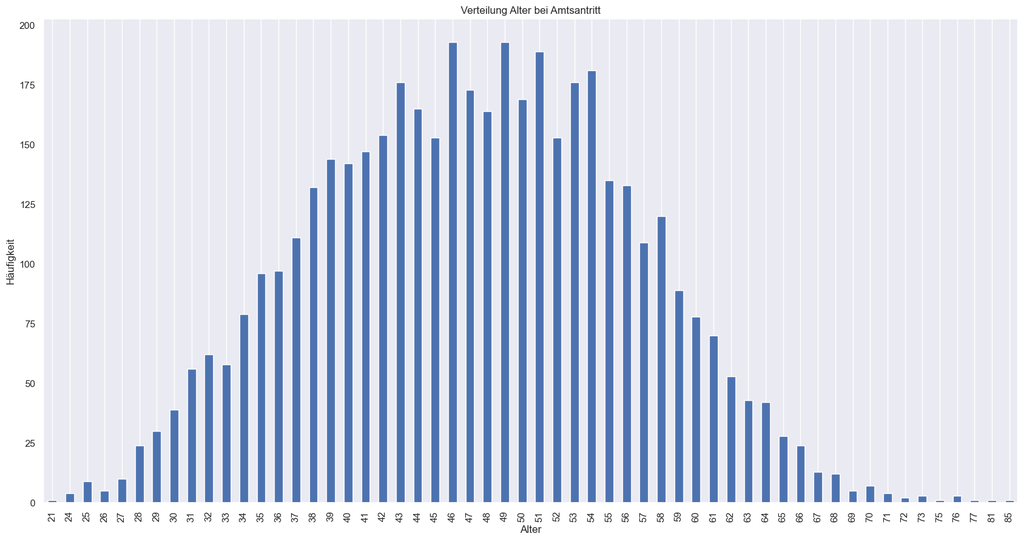

```python
plt.figure(figsize=(20,10))
age_count.plot(kind = 'bar')
plt.title('Verteilung Alter bei Amtsantritt')
plt.xlabel('Alter')
plt.ylabel('Häufigkeit')
plt.grid(axis='y')
```

#### Alter bei Amtsaustritt

```python
df_merged['AgeLeaving'] = df_merged['Austritt'].dt.year - df_merged['DateOfBirth'].dt.year
```

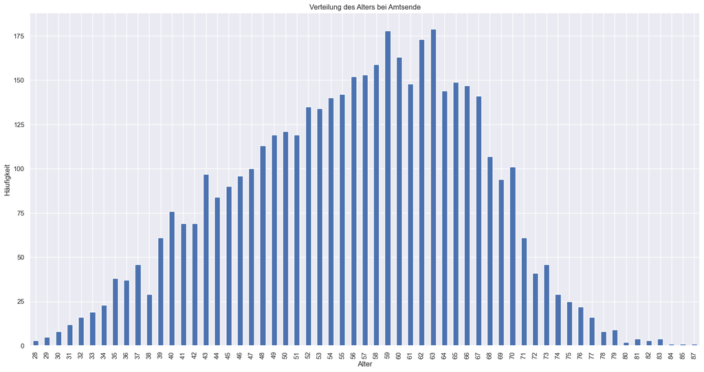

```python
age_count = df_merged['AgeLeaving'].value_counts().sort_index()
plt.figure(figsize=(20,10))
age_count.plot(kind='bar')
plt.title('Verteilung des Alters bei Amtsende')
plt.xlabel('Alter')
plt.ylabel('Häufigkeit')
```

#### Alter der Ratsmitglieder

Nun wird geschaut, wie alt die Ratsmitglieder wurden oder wie alt sie heute sind, falls sie noch leben.

```python
df_merged['Age'] = df_merged['DateOfDeath'].dt.year - df_merged['DateOfBirth'].dt.year
df_merged['Age'] = df_merged['Age'].fillna(2023 - df_merged['DateOfBirth'].dt.year)
df_merged.head()
```

|  | Active | FirstName | LastName | GenderAsString | CantonName | CantonAbbreviation | CouncilName | PartyName | PartyAbbreviation | BirthPlace_City | BirthPlace_Canton | Citizenship | DateOfBirth | DateOfDeath | Personalien | Eintritt | Austritt | AgeJoining | AgeLeaving | Age |
| --- | --- | --- | --- | --- | --- | --- | --- | --- | --- | --- | --- | --- | --- | --- | --- | --- | --- | --- | --- | --- |
| 0 | False | Giuseppe | a Marca | m | Graubünden | GR | Ständerat | Konservative | Kons* | NaN | NaN | Soazza (GR) | 1799-07-29 | 1866-07-16 | Giuseppe a Marca, 29.07.1799 | 1849-12-01 | 1851-07-01 | 50 | 52 | 67.0 |
| 1 | False | Alois | Ab Yberg | m | Schwyz | SZ | Nationalrat | Freisinnig-Demokratische Partei der Schweiz | FDP | NaN | NaN | Schwyz (SZ) | 1878-10-06 | 1959-10-17 | Alois Ab Yberg, 06.10.1878 | 1928-12-03 | 1935-12-01 | 50 | 57 | 81.0 |
| 2 | False | Fabio | Abate | m | Tessin | TI | Nationalrat | Freisinnig-Demokratische Partei der Schweiz | FDP | Locarno | Tessin | Cabbio (TI) | 1966-01-04 | NaT | Fabio Abate, 04.01.1966 | 2000-09-25 | 2011-12-04 | 34 | 45 | 57.0 |
| 4 | False | Fabio | Abate | m | Tessin | TI | Ständerat | FDP.Die Liberalen | FDP-Liberale | Locarno | Tessin | Cabbio (TI) | 1966-01-04 | NaT | Fabio Abate, 04.01.1966 | 2011-12-05 | 2019-12-01 | 45 | 53 | 57.0 |
| 7 | False | Johann Jakob | Abegg | m | Zürich | ZH | Nationalrat | Liberale | Lib* | NaN | NaN | Küsnacht (ZH) | 1834-07-23 | 1912-02-17 | Johann Jakob Abegg, 23.07.1834 | 1887-12-05 | 1912-02-17 | 53 | 78 | 78.0 |

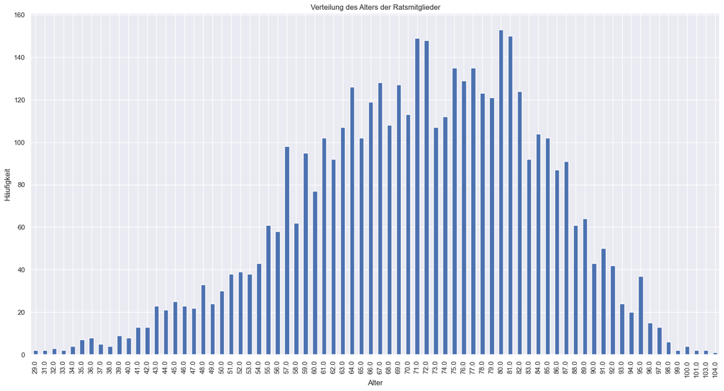

```python
age_count = df_merged['Age'].value_counts().sort_index()
plt.figure(figsize=(20,10))
age_count.plot(kind='bar')
plt.title('Verteilung des Alters der Ratsmitglieder')
plt.xlabel('Alter')
plt.ylabel('Häufigkeit')
```

Es gibt mehrere Personen, welche über 100 Jahre alt wurden. Diese werden später genauer untersucht.

#### Anzahl Jahre im Amt

Nun wird die Anzahl Jahre im Amt berechnet. Dazu wird eine neue Spalte erstellt.

```python
df_merged['YearsInOffice'] = df_merged['Austritt'].dt.year - df_merged['Eintritt'].dt.year
df_merged['YearsInOffice'] = df_merged['YearsInOffice'].fillna(2023 - df_merged['Eintritt'].dt.year)
df_merged.head()
```

|  | Active | FirstName | LastName | GenderAsString | CantonName | CantonAbbreviation | CouncilName | PartyName | PartyAbbreviation | BirthPlace_City | ... | Citizenship | DateOfBirth | DateOfDeath | Personalien | Eintritt | Austritt | AgeJoining | AgeLeaving | Age | YearsInOffice |
| --- | --- | --- | --- | --- | --- | --- | --- | --- | --- | --- | --- | --- | --- | --- | --- | --- | --- | --- | --- | --- | --- |
| 0 | False | Giuseppe | a Marca | m | Graubünden | GR | Ständerat | Konservative | Kons* | NaN | ... | Soazza (GR) | 1799-07-29 | 1866-07-16 | Giuseppe a Marca, 29.07.1799 | 1849-12-01 | 1851-07-01 | 50 | 52 | 67.0 | 2 |
| 1 | False | Alois | Ab Yberg | m | Schwyz | SZ | Nationalrat | Freisinnig-Demokratische Partei der Schweiz | FDP | NaN | ... | Schwyz (SZ) | 1878-10-06 | 1959-10-17 | Alois Ab Yberg, 06.10.1878 | 1928-12-03 | 1935-12-01 | 50 | 57 | 81.0 | 7 |
| 2 | False | Fabio | Abate | m | Tessin | TI | Nationalrat | Freisinnig-Demokratische Partei der Schweiz | FDP | Locarno | ... | Cabbio (TI) | 1966-01-04 | NaT | Fabio Abate, 04.01.1966 | 2000-09-25 | 2011-12-04 | 34 | 45 | 57.0 | 11 |
| 4 | False | Fabio | Abate | m | Tessin | TI | Ständerat | FDP.Die Liberalen | FDP-Liberale | Locarno | ... | Cabbio (TI) | 1966-01-04 | NaT | Fabio Abate, 04.01.1966 | 2011-12-05 | 2019-12-01 | 45 | 53 | 57.0 | 8 |
| 7 | False | Johann Jakob | Abegg | m | Zürich | ZH | Nationalrat | Liberale | Lib* | NaN | ... | Küsnacht (ZH) | 1834-07-23 | 1912-02-17 | Johann Jakob Abegg, 23.07.1834 | 1887-12-05 | 1912-02-17 | 53 | 78 | 78.0 | 25 |

5 rows × 21 columns

Da Personen mehrmals auch in verschiedenen Räten waren, wird die Gesamtzahl pro Person berechnet. Also wie viele Jahre eine Person insgesamt in einem Rat war.

```python
df_merged['YearsInOffice'] = df_merged.groupby(['FirstName', 'LastName', 'DateOfBirth'])['YearsInOffice'].transform('sum')
df_merged
```

|  | Active | FirstName | LastName | GenderAsString | CantonName | CantonAbbreviation | CouncilName | PartyName | PartyAbbreviation | BirthPlace_City | ... | Citizenship | DateOfBirth | DateOfDeath | Personalien | Eintritt | Austritt | AgeJoining | AgeLeaving | Age | YearsInOffice |
| --- | --- | --- | --- | --- | --- | --- | --- | --- | --- | --- | --- | --- | --- | --- | --- | --- | --- | --- | --- | --- | --- |
| 0 | False | Giuseppe | a Marca | m | Graubünden | GR | Ständerat | Konservative | Kons* | NaN | ... | Soazza (GR) | 1799-07-29 | 1866-07-16 | Giuseppe a Marca, 29.07.1799 | 1849-12-01 | 1851-07-01 | 50 | 52 | 67.0 | 2 |
| 1 | False | Alois | Ab Yberg | m | Schwyz | SZ | Nationalrat | Freisinnig-Demokratische Partei der Schweiz | FDP | NaN | ... | Schwyz (SZ) | 1878-10-06 | 1959-10-17 | Alois Ab Yberg, 06.10.1878 | 1928-12-03 | 1935-12-01 | 50 | 57 | 81.0 | 7 |
| 2 | False | Fabio | Abate | m | Tessin | TI | Nationalrat | Freisinnig-Demokratische Partei der Schweiz | FDP | Locarno | ... | Cabbio (TI) | 1966-01-04 | NaT | Fabio Abate, 04.01.1966 | 2000-09-25 | 2011-12-04 | 34 | 45 | 57.0 | 19 |
| 4 | False | Fabio | Abate | m | Tessin | TI | Ständerat | FDP.Die Liberalen | FDP-Liberale | Locarno | ... | Cabbio (TI) | 1966-01-04 | NaT | Fabio Abate, 04.01.1966 | 2011-12-05 | 2019-12-01 | 45 | 53 | 57.0 | 19 |
| 7 | False | Johann Jakob | Abegg | m | Zürich | ZH | Nationalrat | Liberale | Lib* | NaN | ... | Küsnacht (ZH) | 1834-07-23 | 1912-02-17 | Johann Jakob Abegg, 23.07.1834 | 1887-12-05 | 1912-02-17 | 53 | 78 | 78.0 | 25 |
| ... | ... | ... | ... | ... | ... | ... | ... | ... | ... | ... | ... | ... | ... | ... | ... | ... | ... | ... | ... | ... | ... |
| 6711 | False | Peter | Zweifel | m | Glarus | GL | Ständerat | Demokraten | Dem* | NaN | ... | Linthal (GL) | 1833-02-13 | 1907-04-24 | Peter Zweifel, 13.02.1833 | 1890-06-02 | 1907-04-24 | 57 | 74 | 74.0 | 17 |
| 6712 | False | Walter | Zwingli | m | St. Gallen | SG | Nationalrat | Freisinnig-Demokratische Partei der Schweiz | FDP | NaN | ... | Nesslau (SG) | 1925-09-28 | 2018-07-10 | Walter Zwingli, 28.09.1925 | 1984-06-05 | 1991-11-24 | 59 | 66 | 93.0 | 7 |
| 6713 | False | Otto | Zwygart | m | Bern | BE | Nationalrat | Evangelische Volkspartei der Schweiz | EVP | Schliern | ... | Bolligen (BE),Meikirch (BE) | 1940-01-16 | NaT | Otto Zwygart, 16.01.1940 | 1983-11-28 | 2000-09-18 | 43 | 60 | 83.0 | 17 |
| 6714 | False | Otto (senior) | Zwygart | m | Bern | BE | Nationalrat | Evangelische Volkspartei der Schweiz | EVP | NaN | ... | Meikirch (BE) | 1911-05-30 | 1986-04-05 | Otto (senior) Zwygart, 30.05.1911 | 1971-06-01 | 1983-11-27 | 60 | 72 | 75.0 | 12 |
| 6716 | False | Carl Sam. | Zyro | m | Bern | BE | Nationalrat | Freisinnig-Demokratische Partei der Schweiz | FDP | NaN | ... | Thun (BE) | 1834-07-17 | 1896-08-26 | Carl Sam. Zyro, 17.07.1834 | 1866-12-03 | 1893-12-03 | 32 | 59 | 62.0 | 27 |

4462 rows × 21 columns

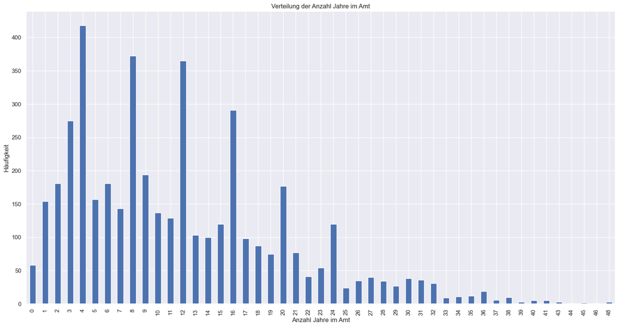

```python
years_in_office_count = df_merged['YearsInOffice'].value_counts().sort_index()
plt.figure(figsize=(20,10))
years_in_office_count.plot(kind='bar')
plt.title('Verteilung der Anzahl Jahre im Amt')
plt.xlabel('Anzahl Jahre im Amt')
plt.ylabel('Häufigkeit')
```

#### 104 Jahre alt?

Bei der vorigen Übersicht der Alter haben wir das Alter von 104 Jahren gesehen. Dieses wird nun genauer untersucht.

```python
max_age = df_merged.query('Age == 104')
max_age
```

|  | Active | FirstName | LastName | GenderAsString | CantonName | CantonAbbreviation | CouncilName | PartyName | PartyAbbreviation | BirthPlace_City | ... | Citizenship | DateOfBirth | DateOfDeath | Personalien | Eintritt | Austritt | AgeJoining | AgeLeaving | Age | YearsInOffice |
| --- | --- | --- | --- | --- | --- | --- | --- | --- | --- | --- | --- | --- | --- | --- | --- | --- | --- | --- | --- | --- | --- |
| 3869 | False | Armand | Melly | m | Waadt | VD | Nationalrat | Freisinnig-Demokratische Partei der Schweiz | FDP | NaN | ... | La Rippe (VD) | 1882-06-20 | 1986-01-18 | Armand Melly, 20.06.1882 | 1939-12-04 | 1947-11-30 | 57 | 65 | 104.0 | 8 |

1 rows × 21 columns

Ein Nachforschen nach Armand Melly ergab, dass diese Daten so stimmen.

#### unter 1 Jahr im Amt?

Bei der Anzahl Jahre im Amt wird zuerst geschaut, ob es sich um einen Fehler handelt oder ob es sich um eine Person handelt, welche nur sehr kurz im Amt war und ob es noch mehrere Personen mit einer Amtszeit von 0 Jahren gibt.

```python
zero_years_in_office = df_merged.query('YearsInOffice == 0')
zero_years_in_office
```

|  | Active | FirstName | LastName | GenderAsString | CantonName | CantonAbbreviation | CouncilName | PartyName | PartyAbbreviation | BirthPlace_City | ... | Citizenship | DateOfBirth | DateOfDeath | Personalien | Eintritt | Austritt | AgeJoining | AgeLeaving | Age | YearsInOffice |
| --- | --- | --- | --- | --- | --- | --- | --- | --- | --- | --- | --- | --- | --- | --- | --- | --- | --- | --- | --- | --- | --- |
| 154 | False | Johann-Kaspar | Ammann | m | Zürich | ZH | Ständerat | Liberale | Lib* | NaN | ... | Unterstrass bei Zürich (ZH),Aussersihl (ZH) | 1803-11-12 | 1870-11-06 | Johann-Kaspar Ammann, 12.11.1803 | 1849-04-16 | 1849-08-01 | 46 | 46 | 67.0 | 0 |
| 157 | False | Regina | Ammann Schoch | f | Aargau | AG | Nationalrat | Landesring der Unabhängigen | LdU | Schaffhausen | ... | Zürich (ZH),Wädenswil (ZH),Oberneunforn (TG) | 1963-06-19 | NaT | Regina Ammann Schoch, 19.06.1963 | 1999-03-01 | 1999-12-05 | 36 | 36 | 60.0 | 0 |
| 242 | False | David E. | Bachelard | m | Waadt | VD | Nationalrat | Freisinnig-Demokratische Partei der Schweiz | FDP | NaN | ... | Nyon (VD),Pampigny (VD) | 1815-08-09 | 1866-06-18 | David E. Bachelard, 09.08.1815 | 1866-05-01 | 1866-06-18 | 51 | 51 | 51.0 | 0 |
| 350 | False | Bonaventura | Baumgartner | m | Solothurn | SO | Nationalrat | Demokraten | Dem* | NaN | ... | Oensingen (SO) | 1822-08-18 | 1884-03-04 | Bonaventura Baumgartner, 18.08.1822 | 1875-03-08 | 1875-06-01 | 53 | 53 | 62.0 | 0 |
| 351 | False | Franz | Baumgartner | m | Zürich | ZH | Nationalrat | Republikanische und nationale Fraktion | N | NaN | ... | Zürich (ZH) | 1926-08-03 | NaT | Franz Baumgartner, 03.08.1926 | 1979-03-05 | 1979-11-25 | 53 | 53 | 97.0 | 0 |
| 553 | False | Karl | Blattner | m | Aargau | AG | Ständerat | Liberale | Lib* | NaN | ... | Küttigen (AG),Aarau (AG) | 1805-12-22 | 1883-06-30 | Karl Blattner, 22.12.1805 | 1849-04-16 | 1849-11-01 | 44 | 44 | 78.0 | 0 |
| 824 | False | Paul | Bruggmann | m | Graubünden | GR | Nationalrat | Konservativ-christlichsoziale Volkspartei der ... | KK | NaN | ... | Degersheim (SG) | 1913-05-10 | 1994-05-11 | Paul Bruggmann, 10.05.1913 | 1959-04-27 | 1959-12-06 | 46 | 46 | 81.0 | 0 |
| 886 | False | Josef | Bühler | m | Luzern | LU | Nationalrat | Liberale | Lib* | NaN | ... | Luzern (LU) | 1837-12-12 | 1873-04-14 | Josef Bühler, 12.12.1837 | 1873-01-01 | 1873-04-14 | 36 | 36 | 36.0 | 0 |
| 985 | False | Guido | Bustelli | m | Tessin | TI | Nationalrat | Freisinnig-Demokratische Partei der Schweiz | FDP | NaN | ... | Locarno (TI) | 1905-04-02 | 1992-03-29 | Guido Bustelli, 02.04.1905 | 1963-06-04 | 1963-12-01 | 58 | 58 | 87.0 | 0 |
| 1059 | False | Nicolas | Carnat | m | Jura | JU | Ständerat | Freisinnig-Demokratische Partei der Schweiz | FDP | NaN | ... | Glovelier (JU) | 1934-06-12 | NaT | Nicolas Carnat, 12.06.1934 | 1995-01-23 | 1995-12-03 | 61 | 61 | 89.0 | 0 |
| 1311 | False | Louis Edouard | Coulin | m | Neuenburg | NE | Nationalrat | Freisinnig-Demokratische Partei der Schweiz | FDP | NaN | ... | Couvet (NE) | 1836-09-22 | 1890-04-17 | Louis Edouard Coulin, 22.09.1836 | 1884-06-04 | 1884-10-01 | 48 | 48 | 54.0 | 0 |
| 1684 | False | Barbara | Eberhard-Halter | f | St. Gallen | SG | Nationalrat | Landesring der Unabhängigen | LdU | NaN | ... | Schänis (SG) | 1945-05-07 | NaT | Barbara Eberhard-Halter, 07.05.1945 | 1995-09-18 | 1995-12-03 | 50 | 50 | 78.0 | 0 |
| 1728 | False | André | Ehrler | m | Genf | GE | Nationalrat | Sozialdemokratische Partei der Schweiz | SP | NaN | ... | Küssnacht am Rigi (SZ) | 1900-01-23 | 1949-04-01 | André Ehrler, 23.01.1900 | 1933-03-28 | 1933-12-01 | 33 | 33 | 49.0 | 0 |
| 2000 | False | Leonhard | Flepp | m | Graubünden | GR | Nationalrat | Christlichdemokratische Volkspartei der Schweiz | CVP | NaN | ... | Disentis/Mustér (GR) | 1923-11-21 | 2003-09-23 | Leonhard Flepp, 21.11.1923 | 1979-06-18 | 1979-11-25 | 56 | 56 | 80.0 | 0 |
| 2042 | False | Jean-Adolphe-Ch. | Fontanel | m | Genf | GE | Ständerat | Freisinnig-Demokratische Partei der Schweiz | FDP | NaN | ... | Carouge (GE) | 1818-04-10 | 1879-04-07 | Jean-Adolphe-Ch. Fontanel, 10.04.1818 | 1853-01-10 | 1853-12-01 | 35 | 35 | 61.0 | 0 |
| 2054 | False | Carl'Antonio | Forni | m | Tessin | TI | Ständerat | Freisinnig-Demokratische Partei der Schweiz | FDP | NaN | ... | Airolo (TI) | 1810-09-16 | 1881-12-04 | Carl'Antonio Forni, 16.09.1810 | 1864-07-04 | 1864-12-01 | 54 | 54 | 71.0 | 0 |
| 2084 | False | Hubert | Frainier | m | Bern | BE | Nationalrat | Christlichdemokratische Volkspartei der Schweiz | CVP | NaN | ... | Fregiécourt (JU) | 1952-10-03 | NaT | Hubert Frainier, 03.10.1952 | 1995-06-19 | 1995-12-03 | 43 | 43 | 71.0 | 0 |
| 2176 | False | Thomas | Fuchs | m | Bern | BE | Nationalrat | Schweizerische Volkspartei | SVP | Bern | ... | Neuenegg (BE) | 1966-06-18 | NaT | Thomas Fuchs, 18.06.1966 | 2011-05-30 | 2011-12-04 | 45 | 45 | 57.0 | 0 |
| 2235 | False | Antonio | Galli | m | Tessin | TI | Nationalrat | Freisinnig-Demokratische Partei der Schweiz | FDP | NaN | ... | Massagno (TI) | 1883-04-24 | 1942-07-28 | Antonio Galli, 24.04.1883 | 1926-02-08 | 1926-09-01 | 43 | 43 | 59.0 | 0 |
| 2236 | False | A. Domenico | Galli | m | Tessin | TI | Ständerat | Freisinnig-Demokratische Partei der Schweiz | FDP | NaN | ... | Locarno (TI) | 1791-07-25 | 1856-02-05 | A. Domenico Galli, 25.07.1791 | 1851-07-07 | 1851-10-01 | 60 | 60 | 65.0 | 0 |
| 2366 | False | Charles-Amédée | Girod | m | Genf | GE | Ständerat | Undefinierbar | ? | NaN | ... | Genf (GE) | 1835-01-01 | 1905-01-01 | Charles-Amédée Girod, 01.01.1835 | 1872-11-01 | 1872-12-01 | 37 | 37 | 70.0 | 0 |
| 2447 | False | Fr.-Xavier | Gottofrey | m | Waadt | VD | Ständerat | Konservative | Kons* | NaN | ... | Echallens (VD) | 1802-09-09 | 1868-12-15 | Fr.-Xavier Gottofrey, 09.09.1802 | 1862-01-13 | 1862-05-01 | 60 | 60 | 66.0 | 0 |
| 3081 | False | Johann | Jakob | m | Appenzell A.-Rh. | AR | Ständerat | Freisinnig-Demokratische Partei der Schweiz | FDP | NaN | ... | Trogen (AR) | 1804-01-29 | 1868-08-17 | Johann Jakob, 29.01.1804 | 1849-04-16 | 1849-10-01 | 45 | 45 | 64.0 | 0 |
| 3169 | False | Ernest | Joray | m | Genf | GE | Nationalrat | Sozialdemokratische Partei der Schweiz | SP | NaN | ... | Belprahon (BE),Versoix (GE) | 1877-05-31 | 1931-06-01 | Ernest Joray, 31.05.1877 | 1922-01-23 | 1922-05-01 | 45 | 45 | 54.0 | 0 |
| 3207 | False | Ruth | Kalbermatten | f | Wallis | VS | Nationalrat | Christlichdemokratische Volkspartei der Schweiz | CVP | Lalden | ... | Baltschieder (VS),Saas-Grund (VS) | 1950-05-09 | 2014-05-16 | Ruth Kalbermatten, 09.05.1950 | 1999-03-01 | 1999-12-05 | 49 | 49 | 64.0 | 0 |
| 3235 | False | Martin | Keiser | m | Zug | ZG | Ständerat | Konservative | Kons* | NaN | ... | Zug (ZG) | 1814-11-14 | 1896-10-28 | Martin Keiser, 14.11.1814 | 1854-01-09 | 1854-07-01 | 40 | 40 | 82.0 | 0 |
| 3275 | False | Alois | Kessler | m | Schwyz | SZ | Nationalrat | Sozialdemokratische Partei der Schweiz | SP | NaN | ... | Schübelbach (SZ) | 1925-10-23 | 1994-01-16 | Alois Kessler, 23.10.1925 | 1979-03-05 | 1979-11-25 | 54 | 54 | 69.0 | 0 |
| 3340 | False | Johann Baptist | Kölbener | m | Appenzell I.-Rh. | AI | Ständerat | Liberale | Lib* | NaN | ... | Appenzell (AI) | 1826-02-06 | 1865-09-07 | Johann Baptist Kölbener, 06.02.1826 | 1865-07-03 | 1865-09-07 | 39 | 39 | 39.0 | 0 |
| 3376 | False | Katrin | Kuhn | f | Aargau | AG | Nationalrat | Grüne Partei der Schweiz | GPS | Zürich | ... | Wohlen (AG) | 1953-08-28 | NaT | Katrin Kuhn, 28.08.1953 | 1999-03-01 | 1999-12-05 | 46 | 46 | 70.0 | 0 |
| 3458 | False | Adolf | Landolt | m | Basel-Landschaft | BL | Nationalrat | Sozialdemokratische Partei der Schweiz | SP | NaN | ... | Näfels (GL) | 1907-01-31 | 1973-10-19 | Adolf Landolt, 31.01.1907 | 1959-06-15 | 1959-12-06 | 52 | 52 | 66.0 | 0 |
| 3699 | False | Marius | Maillard | m | Genf | GE | Nationalrat | Sozialdemokratische Partei der Schweiz | SP | NaN | ... | Genf (GE) | 1889-01-12 | 1959-07-04 | Marius Maillard, 12.01.1889 | 1947-09-22 | 1947-11-30 | 58 | 58 | 70.0 | 0 |
| 3724 | False | Otto | Maraini | m | Tessin | TI | Nationalrat | Freisinnig-Demokratische Partei der Schweiz | FDP | NaN | ... | Lugano (TI) | 1863-11-08 | 1944-01-16 | Otto Maraini, 08.11.1863 | 1922-04-01 | 1922-12-03 | 59 | 59 | 81.0 | 0 |
| 3827 | False | Oscar | Mayer | m | Graubünden | GR | Nationalrat | Sozialdemokratische Partei der Schweiz | SP | NaN | ... | Schleins (GR) | 1916-06-04 | 2011-10-09 | Oscar Mayer, 04.06.1916 | 1963-03-04 | 1963-12-01 | 47 | 47 | 95.0 | 0 |
| 3929 | False | Ludwig Plazid | Meyer | m | Luzern | LU | Ständerat | Liberale | Lib* | NaN | ... | Luzern (LU) | 1807-08-25 | 1871-05-26 | Ludwig Plazid Meyer, 25.08.1807 | 1848-11-06 | 1848-12-01 | 41 | 41 | 64.0 | 0 |
| 3932 | False | Josef | Meyer | m | Luzern | LU | Ständerat | Liberale | Lib* | NaN | ... | Willisau Land (LU) | 1811-01-13 | 1864-10-08 | Josef Meyer, 13.01.1811 | 1849-04-16 | 1849-12-01 | 38 | 38 | 53.0 | 0 |
| 3959 | False | Jürg | Michel | m | Graubünden | GR | Nationalrat | Freisinnig-Demokratische Partei der Schweiz | FDP | Grüsch | ... | Grüsch (GR) | 1955-09-28 | NaT | Jürg Michel, 28.09.1955 | 2007-03-05 | 2007-12-02 | 52 | 52 | 68.0 | 0 |
| 4262 | False | Josef | Nigg | m | Zürich | ZH | Nationalrat | Christlichdemokratische Volkspartei der Schweiz | CVP | NaN | ... | Zürich (ZH),Pfäfers (SG) | 1910-03-09 | 1981-11-13 | Josef Nigg, 09.03.1910 | 1975-06-02 | 1975-11-30 | 65 | 65 | 71.0 | 0 |
| 4375 | False | Tomaso | Pagnamenta | m | Tessin | TI | Nationalrat | Konservative | Kons* | NaN | ... | Frasco (TI) | 1855-06-24 | 1930-12-13 | Tomaso Pagnamenta, 24.06.1855 | 1919-01-27 | 1919-10-01 | 64 | 64 | 75.0 | 0 |
| 4410 | False | Paolo | Pedrazzini | m | Tessin | TI | Nationalrat | Konservative | Kons* | NaN | ... | Campo (Vallemaggia) (TI) | 1889-01-30 | 1956-06-06 | Paolo Pedrazzini, 30.01.1889 | 1925-06-02 | 1925-12-06 | 36 | 36 | 67.0 | 0 |
| 4433 | False | David | Perret | m | Neuenburg | NE | Nationalrat | Freisinnig-Demokratische Partei der Schweiz | FDP | NaN | ... | Le Locle (NE) | 1846-08-19 | 1908-09-18 | David Perret, 19.08.1846 | 1902-06-02 | 1902-11-30 | 56 | 56 | 62.0 | 0 |
| 4435 | False | Paul-Jean | Perret | m | Waadt | VD | Nationalrat | Freisinnig-Demokratische Partei der Schweiz | FDP | NaN | ... | Essertines-sur-Yverdon (VD) | 1880-04-10 | 1947-04-08 | Paul-Jean Perret, 10.04.1880 | 1931-12-01 | 1931-12-22 | 51 | 51 | 67.0 | 0 |
| 4524 | False | Wilhelm Otto | Pfleghard | m | Zürich | ZH | Nationalrat | Freisinnig-Demokratische Partei der Schweiz | FDP | NaN | ... | St. Gallen (SG),Steckborn (TG) | 1869-12-12 | 1958-10-30 | Wilhelm Otto Pfleghard, 12.12.1869 | 1931-06-01 | 1931-12-06 | 62 | 62 | 89.0 | 0 |
| 4631 | False | Marie-Madeleine | Prongué | f | Jura | JU | Ständerat | Christlichdemokratische Volkspartei der Schweiz | CVP | NaN | ... | Buix (JU) | 1939-07-31 | 2019-05-22 | Marie-Madeleine Prongué, 31.07.1939 | 1995-01-23 | 1995-12-03 | 56 | 56 | 80.0 | 0 |
| 4753 | False | David | Revaclier | m | Genf | GE | Nationalrat | Union de défense économique (GE) | UDE | NaN | ... | Laconnex (GE) | 1862-12-23 | 1948-05-23 | David Revaclier, 23.12.1862 | 1931-03-16 | 1931-12-06 | 69 | 69 | 86.0 | 0 |
| 4809 | False | C. Emil | Ringk | m | Schaffhausen | SH | Ständerat | Liberale | Lib* | NaN | ... | Schaffhausen (SH) | 1818-04-05 | 1882-01-22 | C. Emil Ringk, 05.04.1818 | 1859-01-10 | 1859-07-01 | 41 | 41 | 64.0 | 0 |
| 4876 | False | Nicolas | Rochat Fernandez | m | Waadt | VD | Nationalrat | Sozialdemokratische Partei der Schweiz | SP | Lausanne | ... | Le Lieu (VD) | 1982-12-09 | NaT | Nicolas Rochat Fernandez, 09.12.1982 | 2019-05-07 | 2019-12-01 | 37 | 37 | 41.0 | 0 |
| 4881 | False | Ch.-Auguste | Rogivue | m | Waadt | VD | Ständerat | Freisinnig-Demokratische Partei der Schweiz | FDP | NaN | ... | St-Saphorin (Lavaux) (VD),Châtillens (VD),Laus... | 1812-04-06 | 1869-04-24 | Ch.-Auguste Rogivue, 06.04.1812 | 1853-06-01 | 1853-12-01 | 41 | 41 | 57.0 | 0 |
| 4886 | False | Rudolf | Rohr | m | Aargau | AG | Nationalrat | Freisinnig-Demokratische Partei der Schweiz | FDP | NaN | ... | Hunzenschwil (AG) | 1935-02-14 | 2001-10-31 | Rudolf Rohr, 14.02.1935 | 1995-09-18 | 1995-12-03 | 60 | 60 | 66.0 | 0 |
| 4905 | False | Aimé-C. | Rossel | m | Bern | BE | Ständerat | Freisinnig-Demokratische Partei der Schweiz | FDP | NaN | ... | Courtelary (BE) | 1820-09-08 | 1877-09-14 | Aimé-C. Rossel, 08.09.1820 | 1856-01-21 | 1856-12-01 | 36 | 36 | 57.0 | 0 |
| 4995 | False | Laurent | Ruffieux | m | Freiburg | FR | Nationalrat | Bauern-, Gewerbe- und Bürgerpartei | BGB | NaN | ... | Charmey (FR) | 1908-10-28 | 1996-10-27 | Laurent Ruffieux, 28.10.1908 | 1943-04-06 | 1943-12-05 | 35 | 35 | 88.0 | 0 |
| 5122 | False | Anton | Schaller | m | Zürich | ZH | Nationalrat | Landesring der Unabhängigen | LdU | Nottwil | ... | Zürich (ZH),Altbüron (LU) | 1944-10-11 | NaT | Anton Schaller, 11.10.1944 | 1999-04-20 | 1999-12-05 | 55 | 55 | 79.0 | 0 |
| 5219 | False | Robert | Schild | m | Solothurn | SO | Nationalrat | Freisinnig-Demokratische Partei der Schweiz | FDP | NaN | ... | Grenchen (SO) | 1890-11-13 | 1967-09-11 | Robert Schild, 13.11.1890 | 1931-03-16 | 1931-12-06 | 41 | 41 | 77.0 | 0 |
| 5300 | False | Paul | Schmid-Ammann | m | Schaffhausen | SH | Nationalrat | Bauernpartei (nicht BGB) | BP* | NaN | ... | Zürich (ZH) | 1900-02-02 | 1984-09-06 | Paul Schmid-Ammann, 02.02.1900 | 1935-03-26 | 1935-12-01 | 35 | 35 | 84.0 | 0 |
| 5626 | False | Alfred | Stähli | m | Zürich | ZH | Nationalrat | Sozialdemokratische Partei der Schweiz | SP | NaN | ... | Zürich (ZH) | 1902-11-13 | 1982-04-11 | Alfred Stähli, 13.11.1902 | 1947-06-02 | 1947-11-30 | 45 | 45 | 80.0 | 0 |
| 6489 | False | Johann Jakob | Wieland | m | Zürich | ZH | Nationalrat | Liberale | Lib* | NaN | ... | Thalwil (ZH) | 1783-01-01 | 1848-12-31 | Johann Jakob Wieland, 01.01.1783 | 1848-11-06 | 1848-12-31 | 65 | 65 | 65.0 | 0 |
| 6507 | False | Rudolf | Winkler | m | Zürich | ZH | Nationalrat | Bürgerlich-Demokratische Partei Schweiz | BDP | Schwerzenbach | ... | Schwerzenbach (ZH) | 1955-11-26 | NaT | Rudolf Winkler, 26.11.1955 | 2015-03-02 | 2015-11-29 | 60 | 60 | 68.0 | 0 |
| 6520 | False | Hans | Wirz | m | Zürich | ZH | Nationalrat | Sozialdemokratische Partei der Schweiz | SP | NaN | ... | Gossau (ZH) | 1873-05-21 | 1943-01-16 | Hans Wirz, 21.05.1873 | 1919-01-27 | 1919-10-01 | 46 | 46 | 70.0 | 0 |
| 6643 | False | Theodor | Ziegler | m | Zürich | ZH | Ständerat | Freisinnig-Demokratische Partei der Schweiz | FDP | NaN | ... | Winterthur (ZH) | 1832-09-03 | 1917-12-09 | Theodor Ziegler, 03.09.1832 | 1869-07-05 | 1869-12-05 | 37 | 37 | 85.0 | 0 |

58 rows × 21 columns

Es sind 58 Observationen für Personen, welche weniger als ein Jahr im jeweiligen Rat waren. Für den Moment lassen wir dies so stehen.

#### 48 Jahre im Amt?

Wir wollen nun schauen, welche Person 48 Jahre im Amt war und ob dies stimmt.

```python
most_years_in_office = df_merged.query('YearsInOffice == 48')
most_years_in_office
```

|  | Active | FirstName | LastName | GenderAsString | CantonName | CantonAbbreviation | CouncilName | PartyName | PartyAbbreviation | BirthPlace_City | ... | Citizenship | DateOfBirth | DateOfDeath | Personalien | Eintritt | Austritt | AgeJoining | AgeLeaving | Age | YearsInOffice |
| --- | --- | --- | --- | --- | --- | --- | --- | --- | --- | --- | --- | --- | --- | --- | --- | --- | --- | --- | --- | --- | --- |
| 2861 | False | Josef | Hildebrand | m | Zug | ZG | Ständerat | Konservative | Kons* | NaN | ... | Cham (ZG) | 1855-06-28 | 1935-03-16 | Josef Hildebrand, 28.06.1855 | 1886-06-07 | 1934-12-01 | 31 | 79 | 80.0 | 48 |
| 3044 | False | P. Emil | Isler | m | Aargau | AG | Nationalrat | Freisinnig-Demokratische Partei der Schweiz | FDP | NaN | ... | Wohlen (AG),Aarau (AG) | 1851-01-31 | 1936-03-10 | P. Emil Isler, 31.01.1851 | 1884-12-01 | 1890-11-30 | 33 | 39 | 85.0 | 48 |
| 3048 | False | P. Emil | Isler | m | Aargau | AG | Ständerat | Freisinnig-Demokratische Partei der Schweiz | FDP | NaN | ... | Wohlen (AG),Aarau (AG) | 1851-01-31 | 1936-03-10 | P. Emil Isler, 31.01.1851 | 1890-12-01 | 1932-12-31 | 39 | 81 | 85.0 | 48 |

3 rows × 21 columns

Josef Hildebrand war tatsächlich fast sein ganzes Leben lang Ständerat. Ebenso Peter Emil Isler.

#### über Hundertjährige

Beim Alter werden alle Werte über 100 Jahren genauer untersucht.

```python
df_merged[df_merged['Age'] > 100]
```

|  | Active | FirstName | LastName | GenderAsString | CantonName | CantonAbbreviation | CouncilName | PartyName | PartyAbbreviation | BirthPlace_City | ... | Citizenship | DateOfBirth | DateOfDeath | Personalien | Eintritt | Austritt | AgeJoining | AgeLeaving | Age | YearsInOffice |
| --- | --- | --- | --- | --- | --- | --- | --- | --- | --- | --- | --- | --- | --- | --- | --- | --- | --- | --- | --- | --- | --- |
| 177 | False | Othmar | Andermatt | m | Zug | ZG | Ständerat | Freisinnig-Demokratische Partei der Schweiz | FDP | NaN | ... | Luzern (LU),Baar (ZG) | 1922-11-08 | NaT | Othmar Andermatt, 08.11.1922 | 1971-01-25 | 1986-12-01 | 49 | 64 | 101.0 | 15 |
| 730 | False | Samuel | Brawand | m | Bern | BE | Nationalrat | Sozialdemokratische Partei der Schweiz | SP | NaN | ... | Grindelwald (BE) | 1898-05-18 | 2001-07-11 | Samuel Brawand, 18.05.1898 | 1935-12-02 | 1947-11-30 | 37 | 49 | 103.0 | 24 |
| 731 | False | Samuel | Brawand | m | Bern | BE | Nationalrat | Sozialdemokratische Partei der Schweiz | SP | NaN | ... | Grindelwald (BE) | 1898-05-18 | 2001-07-11 | Samuel Brawand, 18.05.1898 | 1955-12-05 | 1967-12-03 | 57 | 69 | 103.0 | 24 |
| 2787 | False | Albin | Heimann | m | Zürich | ZH | Ständerat | Landesring der Unabhängigen | LdU | NaN | ... | Zürich (ZH),Hasliberg (BE) | 1914-03-16 | 2015-12-19 | Albin Heimann, 16.03.1914 | 1967-12-04 | 1979-11-25 | 53 | 65 | 101.0 | 12 |
| 3869 | False | Armand | Melly | m | Waadt | VD | Nationalrat | Freisinnig-Demokratische Partei der Schweiz | FDP | NaN | ... | La Rippe (VD) | 1882-06-20 | 1986-01-18 | Armand Melly, 20.06.1882 | 1939-12-04 | 1947-11-30 | 57 | 65 | 104.0 | 8 |

5 rows × 21 columns

Eine Überprüfung des Alters von Armand Melly haben wir bereits gemacht. Die einzige über hundert jährige Person ohne Todesdatum ist Othmar Andermatt. Er lebt heute noch. Bei den weiteren Personen dürfte das Alter ebenfalls stimmen.

#### Nur 2 Tag im Amt?

Um die Zeit weniger als 1 Jahr im Amt zu untersuchen, wird eine neue Spalte mit den Tagen im Amt erstellt.

```python
df_merged['DaysInOffice'] = df_merged['Austritt'] - df_merged['Eintritt']
df_merged['DaysInOffice'] = df_merged['DaysInOffice'].fillna(pd.Timestamp('2023-12-31') - df_merged['Eintritt'])
df_merged
```

|  | Active | FirstName | LastName | GenderAsString | CantonName | CantonAbbreviation | CouncilName | PartyName | PartyAbbreviation | BirthPlace_City | ... | DateOfBirth | DateOfDeath | Personalien | Eintritt | Austritt | AgeJoining | AgeLeaving | Age | YearsInOffice | DaysInOffice |
| --- | --- | --- | --- | --- | --- | --- | --- | --- | --- | --- | --- | --- | --- | --- | --- | --- | --- | --- | --- | --- | --- |
| 0 | False | Giuseppe | a Marca | m | Graubünden | GR | Ständerat | Konservative | Kons* | NaN | ... | 1799-07-29 | 1866-07-16 | Giuseppe a Marca, 29.07.1799 | 1849-12-01 | 1851-07-01 | 50 | 52 | 67.0 | 2 | 577 days |
| 1 | False | Alois | Ab Yberg | m | Schwyz | SZ | Nationalrat | Freisinnig-Demokratische Partei der Schweiz | FDP | NaN | ... | 1878-10-06 | 1959-10-17 | Alois Ab Yberg, 06.10.1878 | 1928-12-03 | 1935-12-01 | 50 | 57 | 81.0 | 7 | 2554 days |
| 2 | False | Fabio | Abate | m | Tessin | TI | Nationalrat | Freisinnig-Demokratische Partei der Schweiz | FDP | Locarno | ... | 1966-01-04 | NaT | Fabio Abate, 04.01.1966 | 2000-09-25 | 2011-12-04 | 34 | 45 | 57.0 | 19 | 4087 days |
| 4 | False | Fabio | Abate | m | Tessin | TI | Ständerat | FDP.Die Liberalen | FDP-Liberale | Locarno | ... | 1966-01-04 | NaT | Fabio Abate, 04.01.1966 | 2011-12-05 | 2019-12-01 | 45 | 53 | 57.0 | 19 | 2918 days |
| 7 | False | Johann Jakob | Abegg | m | Zürich | ZH | Nationalrat | Liberale | Lib* | NaN | ... | 1834-07-23 | 1912-02-17 | Johann Jakob Abegg, 23.07.1834 | 1887-12-05 | 1912-02-17 | 53 | 78 | 78.0 | 25 | 8839 days |
| ... | ... | ... | ... | ... | ... | ... | ... | ... | ... | ... | ... | ... | ... | ... | ... | ... | ... | ... | ... | ... | ... |
| 6711 | False | Peter | Zweifel | m | Glarus | GL | Ständerat | Demokraten | Dem* | NaN | ... | 1833-02-13 | 1907-04-24 | Peter Zweifel, 13.02.1833 | 1890-06-02 | 1907-04-24 | 57 | 74 | 74.0 | 17 | 6169 days |
| 6712 | False | Walter | Zwingli | m | St. Gallen | SG | Nationalrat | Freisinnig-Demokratische Partei der Schweiz | FDP | NaN | ... | 1925-09-28 | 2018-07-10 | Walter Zwingli, 28.09.1925 | 1984-06-05 | 1991-11-24 | 59 | 66 | 93.0 | 7 | 2728 days |
| 6713 | False | Otto | Zwygart | m | Bern | BE | Nationalrat | Evangelische Volkspartei der Schweiz | EVP | Schliern | ... | 1940-01-16 | NaT | Otto Zwygart, 16.01.1940 | 1983-11-28 | 2000-09-18 | 43 | 60 | 83.0 | 17 | 6139 days |
| 6714 | False | Otto (senior) | Zwygart | m | Bern | BE | Nationalrat | Evangelische Volkspartei der Schweiz | EVP | NaN | ... | 1911-05-30 | 1986-04-05 | Otto (senior) Zwygart, 30.05.1911 | 1971-06-01 | 1983-11-27 | 60 | 72 | 75.0 | 12 | 4562 days |
| 6716 | False | Carl Sam. | Zyro | m | Bern | BE | Nationalrat | Freisinnig-Demokratische Partei der Schweiz | FDP | NaN | ... | 1834-07-17 | 1896-08-26 | Carl Sam. Zyro, 17.07.1834 | 1866-12-03 | 1893-12-03 | 32 | 59 | 62.0 | 27 | 9862 days |

4462 rows × 22 columns

Verena Diener ist die Person, die gemäss diesen Daten nur zwei Tage im Nationalrat war, was so bekanntlich nicht stimmt. An ihrem Beispiel wird untersucht, wie die Daten DateJoining und Dateleaving zu verstehen sind.

```python
verena = df_merged.query('FirstName == "Verena" and LastName == "Diener"')
verena
```

|  | Active | FirstName | LastName | GenderAsString | CantonName | CantonAbbreviation | CouncilName | PartyName | PartyAbbreviation | BirthPlace_City | ... | DateOfBirth | DateOfDeath | Personalien | Eintritt | Austritt | AgeJoining | AgeLeaving | Age | YearsInOffice | DaysInOffice |
| --- | --- | --- | --- | --- | --- | --- | --- | --- | --- | --- | --- | --- | --- | --- | --- | --- | --- | --- | --- | --- | --- |
| 1552 | False | Verena | Diener | f | Zürich | ZH | Nationalrat | Grünliberale Partei | glp | Zürich | ... | 1949-03-27 | NaT | Verena Diener, 27.03.1949 | 1987-11-30 | 1998-04-26 | 38 | 49 | 74.0 | 15 | 3800 days |
| 1553 | False | Verena | Diener | f | Zürich | ZH | Nationalrat | Grünliberale Partei | glp | Zürich | ... | 1949-03-27 | NaT | Verena Diener, 27.03.1949 | 2007-12-03 | 2007-12-05 | 58 | 58 | 74.0 | 15 | 2 days |
| 1556 | False | Verena | Diener | f | Zürich | ZH | Ständerat | Grünliberale Partei | glp | Zürich | ... | 1949-03-27 | NaT | Verena Diener, 27.03.1949 | 2007-12-06 | 2011-12-04 | 58 | 62 | 74.0 | 15 | 1459 days |

3 rows × 22 columns

An diesem Beispiel sieht man gut, dass die Daten bei jeder (Wieder-)Wahl erfasst wurden und beim Übertritt von Nationalrat in den Ständerat die Tage dazwischen als zusätzliche Observation erfasst wurde.

Bei den Datumsformaten und den daraus berechneten zusätzlichen Spalten sind keine weiteren Ungereimtheiten mehr ersichtlich.

#### kategoriale Variablen

Umgewandelt werden:

- GenderAsString
- CouncilName

```python
# Datentypen anpassen
# columns_to_convert = ['GenderAsString', 'CantonName', 'CantonAbbreviation', 'CouncilName', 'PartyName', 'PartyAbbreviation']
columns_to_convert = ['GenderAsString', 'CouncilName']
for col in columns_to_convert:
    df_merged[col] = df_merged[col].astype('category')

df_merged.info()
```

```
<class 'pandas.core.frame.DataFrame'>
Index: 4462 entries, 0 to 6716
Data columns (total 22 columns):
 #   Column              Non-Null Count  Dtype
---  ------              --------------  -----
 0   Active              4462 non-null   bool
 1   FirstName           4462 non-null   object
 2   LastName            4462 non-null   object
 3   GenderAsString      4462 non-null   category
 4   CantonName          4462 non-null   object
 5   CantonAbbreviation  4462 non-null   object
 6   CouncilName         4462 non-null   category
 7   PartyName           4428 non-null   object
 8   PartyAbbreviation   4428 non-null   object
 9   BirthPlace_City     955 non-null    object
 10  BirthPlace_Canton   920 non-null    object
 11  Citizenship         4457 non-null   object
 12  DateOfBirth         4462 non-null   datetime64[ns]
 13  DateOfDeath         3438 non-null   datetime64[ns]
 14  Personalien         4462 non-null   object
 15  Eintritt            4462 non-null   datetime64[ns]
 16  Austritt            4462 non-null   datetime64[ns]
 17  AgeJoining          4462 non-null   int32
 18  AgeLeaving          4462 non-null   int32
 19  Age                 4462 non-null   float64
 20  YearsInOffice       4462 non-null   int32
 21  DaysInOffice        4462 non-null   timedelta64[ns]
dtypes: bool(1), category(2), datetime64[ns](4), float64(1), int32(3), object(10), timedelta64[ns](1)
memory usage: 658.3+ KB
```

Die Spalten 'Active' und 'Austritt' hängen zusammen. Denn wenn eine Person aktiv ist, sollte sie kein Datum in 'Austritt' haben und umgekehrt. für die Überprüfung dieses Umstandes wird eine Kontrollspalte angefügt. In dieser neuen Spalte wird der boolische Wert True vergeben, wenn die beiden Werte übereinstimmen. False bei Unstimmigkeiten.

```python
df_merged['CheckActive'] = ((df_merged['Active'] == False) & (df_merged['Austritt'] == pd.Timestamp('2023-12-31'))) | \
                           ((df_merged['Active'] == True) & (df_merged['Austritt'] <= pd.Timestamp('2023-12-31')))

df_merged
```

|  | Active | FirstName | LastName | GenderAsString | CantonName | CantonAbbreviation | CouncilName | PartyName | PartyAbbreviation | BirthPlace_City | ... | DateOfDeath | Personalien | Eintritt | Austritt | AgeJoining | AgeLeaving | Age | YearsInOffice | DaysInOffice | CheckActive |
| --- | --- | --- | --- | --- | --- | --- | --- | --- | --- | --- | --- | --- | --- | --- | --- | --- | --- | --- | --- | --- | --- |
| 0 | False | Giuseppe | a Marca | m | Graubünden | GR | Ständerat | Konservative | Kons* | NaN | ... | 1866-07-16 | Giuseppe a Marca, 29.07.1799 | 1849-12-01 | 1851-07-01 | 50 | 52 | 67.0 | 2 | 577 days | False |
| 1 | False | Alois | Ab Yberg | m | Schwyz | SZ | Nationalrat | Freisinnig-Demokratische Partei der Schweiz | FDP | NaN | ... | 1959-10-17 | Alois Ab Yberg, 06.10.1878 | 1928-12-03 | 1935-12-01 | 50 | 57 | 81.0 | 7 | 2554 days | False |
| 2 | False | Fabio | Abate | m | Tessin | TI | Nationalrat | Freisinnig-Demokratische Partei der Schweiz | FDP | Locarno | ... | NaT | Fabio Abate, 04.01.1966 | 2000-09-25 | 2011-12-04 | 34 | 45 | 57.0 | 19 | 4087 days | False |
| 4 | False | Fabio | Abate | m | Tessin | TI | Ständerat | FDP.Die Liberalen | FDP-Liberale | Locarno | ... | NaT | Fabio Abate, 04.01.1966 | 2011-12-05 | 2019-12-01 | 45 | 53 | 57.0 | 19 | 2918 days | False |
| 7 | False | Johann Jakob | Abegg | m | Zürich | ZH | Nationalrat | Liberale | Lib* | NaN | ... | 1912-02-17 | Johann Jakob Abegg, 23.07.1834 | 1887-12-05 | 1912-02-17 | 53 | 78 | 78.0 | 25 | 8839 days | False |
| ... | ... | ... | ... | ... | ... | ... | ... | ... | ... | ... | ... | ... | ... | ... | ... | ... | ... | ... | ... | ... | ... |
| 6711 | False | Peter | Zweifel | m | Glarus | GL | Ständerat | Demokraten | Dem* | NaN | ... | 1907-04-24 | Peter Zweifel, 13.02.1833 | 1890-06-02 | 1907-04-24 | 57 | 74 | 74.0 | 17 | 6169 days | False |
| 6712 | False | Walter | Zwingli | m | St. Gallen | SG | Nationalrat | Freisinnig-Demokratische Partei der Schweiz | FDP | NaN | ... | 2018-07-10 | Walter Zwingli, 28.09.1925 | 1984-06-05 | 1991-11-24 | 59 | 66 | 93.0 | 7 | 2728 days | False |
| 6713 | False | Otto | Zwygart | m | Bern | BE | Nationalrat | Evangelische Volkspartei der Schweiz | EVP | Schliern | ... | NaT | Otto Zwygart, 16.01.1940 | 1983-11-28 | 2000-09-18 | 43 | 60 | 83.0 | 17 | 6139 days | False |
| 6714 | False | Otto (senior) | Zwygart | m | Bern | BE | Nationalrat | Evangelische Volkspartei der Schweiz | EVP | NaN | ... | 1986-04-05 | Otto (senior) Zwygart, 30.05.1911 | 1971-06-01 | 1983-11-27 | 60 | 72 | 75.0 | 12 | 4562 days | False |
| 6716 | False | Carl Sam. | Zyro | m | Bern | BE | Nationalrat | Freisinnig-Demokratische Partei der Schweiz | FDP | NaN | ... | 1896-08-26 | Carl Sam. Zyro, 17.07.1834 | 1866-12-03 | 1893-12-03 | 32 | 59 | 62.0 | 27 | 9862 days | False |

4462 rows × 23 columns

```python
values_count = df_merged['CheckActive'].value_counts()
values_count
```

```
CheckActive
False    4208
True      254
Name: count, dtype: int64
```

Nun sind nur noch die aktuellen Ratsmitglieder mit dem Wert True vorhanden.

```python
df_merged = df_merged.drop(columns=['Active'])
df_merged = df_merged.rename(columns={'CheckActive':'Active'})
```

Für die Beantwortung der Fragestellungen werden die Daten zum Bundeskanzler nicht benötigt und können deshalb aus dem Datensatz entfernt werden.

```python
df_merged = df_merged[df_merged['CouncilName'] != 'Bundeskanzler']
```

Die Bereinigung der Daten ist abgeschlossen. Nun wird das Datenset in das df_final gespeichert.

```python
df_final = df_merged.copy()
df_final.isna().sum()
```

```
FirstName                0
LastName                 0
GenderAsString           0
CantonName               0
CantonAbbreviation       0
CouncilName              0
PartyName               34
PartyAbbreviation       34
BirthPlace_City       3507
BirthPlace_Canton     3542
Citizenship              4
DateOfBirth              0
DateOfDeath           1022
Personalien              0
Eintritt                 0
Austritt                 0
AgeJoining               0
AgeLeaving               0
Age                      0
YearsInOffice            0
DaysInOffice             0
Active                   0
dtype: int64
```

## 2.2 Fragestellungen

#### 2.2.1 Wer war von wann bis wann in welchem Rat?

Es wird eine Liste erstellt mit folgender Struktur: Name, Vorname, Kanton, Erster Eintritt in Nationalrat, Letzter Austritt aus Nationalrat, Erster Eintritt in Ständerat, Letzter Austritt aus Ständerat, Erster Eintritt in Bundesrat, Letzter Austritt aus Bundesrat

```python
# Liste mit den Ratsmitgliedern erstellen
list_1_agg = df_final.groupby(['Personalien', 'CantonName', 'CouncilName'], observed = True).agg({'Eintritt': 'min', 'Austritt': 'max'}).reset_index().dropna()
list_1_agg
```

|  | Personalien | CantonName | CouncilName | Eintritt | Austritt |
| --- | --- | --- | --- | --- | --- |
| 0 | A. Domenico Galli, 25.07.1791 | Tessin | Ständerat | 1851-07-07 | 1851-10-01 |
| 1 | A. Eduard Fehr, 08.05.1879 | Thurgau | Nationalrat | 1920-02-02 | 1922-12-03 |
| 2 | A. Frédéric E. Soguel, 06.05.1841 | Neuenburg | Nationalrat | 1902-12-01 | 1903-11-21 |
| 3 | A. Frédéric E. Soguel, 06.05.1841 | Neuenburg | Ständerat | 1875-06-07 | 1876-07-01 |
| 4 | A. Giovanni Jauch, 22.03.1806 | Tessin | Nationalrat | 1848-11-06 | 1873-03-01 |
| ... | ... | ... | ... | ... | ... |
| 4046 | Yvette Jaggi, 11.02.1941 | Waadt | Ständerat | 1987-11-30 | 1991-11-24 |
| 4047 | Yvonne Feri, 21.03.1966 | Aargau | Nationalrat | 2011-12-05 | 2023-12-31 |
| 4048 | Yvonne Gilli, 07.03.1957 | St. Gallen | Nationalrat | 2007-12-03 | 2015-11-29 |
| 4049 | Zacharias Gysel, 25.01.1818 | Schaffhausen | Ständerat | 1848-11-06 | 1857-07-01 |
| 4050 | Zélim Perret, 29.07.1823 | Neuenburg | Nationalrat | 1869-12-06 | 1875-12-05 |

4051 rows × 5 columns

Nun wird aus dieser aggregierten Tabelle eine Pivottabelle erstellt, welche den Vorgaben aus der Fragestellungen entspricht. Die dadurch entstehenden fehlenden Werte werden mit NaT belassen.

```python
list_1_pivot = pd.pivot_table(list_1_agg, values=["Eintritt", "Austritt"], index=["Personalien", "CantonName"], columns=["CouncilName"])

new_columns = []
for col in list_1_pivot.columns:
    if col[0] == "Eintritt":
        new_col = f"Erster Eintritt {col[1]}"
    elif col[0] == "Austritt":
        new_col = f"Letzter Austritt {col[1]}"
    new_columns.append(new_col)

list_1_pivot.columns = new_columns

list_1_pivot.reset_index(inplace=True)
list_1_pivot = list_1_pivot[['Personalien', 'CantonName', 'Erster Eintritt Nationalrat', 'Letzter Austritt Nationalrat', 'Erster Eintritt Ständerat', 'Letzter Austritt Ständerat', 'Erster Eintritt Bundesrat', 'Letzter Austritt Bundesrat']]
list_1_pivot
```

|  | Personalien | CantonName | Erster Eintritt Nationalrat | Letzter Austritt Nationalrat | Erster Eintritt Ständerat | Letzter Austritt Ständerat | Erster Eintritt Bundesrat | Letzter Austritt Bundesrat |
| --- | --- | --- | --- | --- | --- | --- | --- | --- |
| 0 | A. Domenico Galli, 25.07.1791 | Tessin | NaT | NaT | 1851-07-07 | 1851-10-01 | NaT | NaT |
| 1 | A. Eduard Fehr, 08.05.1879 | Thurgau | 1920-02-02 | 1922-12-03 | NaT | NaT | NaT | NaT |
| 2 | A. Frédéric E. Soguel, 06.05.1841 | Neuenburg | 1902-12-01 | 1903-11-21 | 1875-06-07 | 1876-07-01 | NaT | NaT |
| 3 | A. Giovanni Jauch, 22.03.1806 | Tessin | 1848-11-06 | 1873-03-01 | 1874-05-28 | 1875-03-01 | NaT | NaT |
| 4 | A. Otto Aepli, 18.04.1870 | Thurgau | NaT | NaT | 1919-01-27 | 1921-11-04 | NaT | NaT |
| ... | ... | ... | ... | ... | ... | ... | ... | ... |
| 3630 | Yvette Jaggi, 11.02.1941 | Waadt | 1979-11-26 | 1987-11-29 | 1987-11-30 | 1991-11-24 | NaT | NaT |
| 3631 | Yvonne Feri, 21.03.1966 | Aargau | 2011-12-05 | 2023-12-31 | NaT | NaT | NaT | NaT |
| 3632 | Yvonne Gilli, 07.03.1957 | St. Gallen | 2007-12-03 | 2015-11-29 | NaT | NaT | NaT | NaT |
| 3633 | Zacharias Gysel, 25.01.1818 | Schaffhausen | NaT | NaT | 1848-11-06 | 1857-07-01 | NaT | NaT |
| 3634 | Zélim Perret, 29.07.1823 | Neuenburg | 1869-12-06 | 1875-12-05 | NaT | NaT | NaT | NaT |

3635 rows × 8 columns

## Bundesrät:innen im 1995

```python
# # Liste mit Bundesräten im 1995
list_bundesrat_95 = list_1_agg.query('CouncilName == "Bundesrat"')
target_date = pd.Timestamp('1995-01-01')
list_bundesrat_95 = list_bundesrat_95[(list_bundesrat_95['Eintritt'] <= target_date) & (list_bundesrat_95['Austritt'] >= target_date)]
list_bundesrat_95
```

|  | Personalien | CantonName | CouncilName | Eintritt | Austritt |
| --- | --- | --- | --- | --- | --- |
| 50 | Adolf Ogi, 18.07.1942 | Bern | Bundesrat | 1988-01-01 | 2000-12-31 |
| 393 | Arnold Koller, 29.08.1933 | Appenzell I.-Rh. | Bundesrat | 1987-01-01 | 1999-04-30 |
| 1133 | Flavio Cotti, 18.10.1939 | Tessin | Bundesrat | 1987-01-01 | 1999-04-30 |
| 2112 | Jean-Pascal Delamuraz, 01.04.1936 | Waadt | Bundesrat | 1983-12-07 | 1998-03-31 |
| 2683 | Kaspar Villiger, 05.02.1941 | Luzern | Bundesrat | 1989-02-01 | 2003-12-10 |
| 3168 | Otto Stich, 10.01.1927 | Solothurn | Bundesrat | 1983-12-07 | 1995-10-31 |
| 3624 | Ruth Dreifuss, 09.01.1940 | Genf | Bundesrat | 1993-04-01 | 2002-12-31 |

#### 2.2.2 Wer war am längsten in einem Rat?

Es wird eine Liste erstellt mit folgender Struktur: Name, Vorname, Kanton, Rat, Anzahl Jahre im Rat (ohne Unterbrüche), Datum Amtsantritt, Datum Amtsaustritt

```python
df_question_2 = df_final[['Personalien', 'CantonName', 'CouncilName', 'Eintritt', 'Austritt']].copy()
df_question_2['Anzahl_Jahre_im_Rat'] = df_question_2['Austritt'].dt.year - df_question_2['Eintritt'].dt.year
df_question_2 = df_question_2[['Personalien', 'CantonName', 'CouncilName', 'Anzahl_Jahre_im_Rat', 'Eintritt', 'Austritt']].sort_values(by=['Anzahl_Jahre_im_Rat'], ascending=False)
df_question_2
```

|  | Personalien | CantonName | CouncilName | Anzahl_Jahre_im_Rat | Eintritt | Austritt |
| --- | --- | --- | --- | --- | --- | --- |
| 2861 | Josef Hildebrand, 28.06.1855 | Zug | Ständerat | 48 | 1886-06-07 | 1934-12-01 |
| 782 | Walther Bringolf, 01.08.1895 | Schaffhausen | Nationalrat | 46 | 1925-12-07 | 1971-11-28 |
| 725 | Robert Bratschi, 06.02.1891 | Bern | Nationalrat | 45 | 1922-12-04 | 1967-12-03 |
| 3134 | Johann Jenny, 08.09.1857 | Bern | Nationalrat | 45 | 1890-12-01 | 1935-12-01 |
| 1458 | Louis de Wuilleret, 25.12.1815 | Freiburg | Nationalrat | 44 | 1854-01-09 | 1898-02-23 |
| ... | ... | ... | ... | ... | ... | ... |
| 3724 | Otto Maraini, 08.11.1863 | Tessin | Nationalrat | 0 | 1922-04-01 | 1922-12-03 |
| 4832 | Jakob Ulrich Ritter, 10.01.1810 | St. Gallen | Nationalrat | 0 | 1851-07-07 | 1851-10-01 |
| 3699 | Marius Maillard, 12.01.1889 | Genf | Nationalrat | 0 | 1947-09-22 | 1947-11-30 |
| 4846 | M.-Eugène Ritzchel, 05.07.1856 | Genf | Ständerat | 0 | 1899-06-06 | 1899-10-01 |
| 5300 | Paul Schmid-Ammann, 02.02.1900 | Schaffhausen | Nationalrat | 0 | 1935-03-26 | 1935-12-01 |

4459 rows × 6 columns

#### Wer war am längsten im Bundesrat, Nationalrat und Ständerat?

Eine Funktion wird erstellt, welche die Anzahl Jahre im Rat ohne Unterbrüche berechnet.

```python
# Funktion für die Berechnung der Anzahl Jahre im Rat ohne Unterbrüche
def longest_time_in_office_without_gaps(group):
    group = group.sort_values(by=['Eintritt'])
    longest_period = pd.Timedelta(0)

    current_start = group.iloc[0]['Eintritt']
    current_end = group.iloc[0]['Austritt']

    for index, row in group.iterrows():
        if row['Eintritt'] <= current_end:
            current_end = max(current_end, row['Austritt'])
        else:
            longest_period = max(longest_period, current_end - current_start)
            current_start, current_end = row['Eintritt'], row['Austritt']

    longest_period = max(longest_period, current_end - current_start)
    return round(longest_period.days / 365.25)
```

Aufruf der Funktion und Ausgabe der jeweiligen Räte mit den Personen, welche am längsten im jeweiligen Rat waren.

```python
list_2 = df_final.copy()
result = list_2.groupby(['Personalien', 'CouncilName'], observed = True).apply(longest_time_in_office_without_gaps).reset_index(name='YearsInOffice')
# result_max_per_council = result[result.groupby('CouncilName', observed = True)['YearsInOffice'].transform(max) == result['YearsInOffice']]
result_max_per_council = result[result.groupby('CouncilName', observed=True)['YearsInOffice'].transform('max') == result['YearsInOffice']]
result_max_per_council
```

|  | Personalien | CouncilName | YearsInOffice |
| --- | --- | --- | --- |
| 2443 | Josef Hildebrand, 28.06.1855 | Ständerat | 48 |
| 2652 | Karl Schenk, 01.12.1823 | Bundesrat | 32 |
| 3964 | Walther Bringolf, 01.08.1895 | Nationalrat | 46 |

## 2.2.3 Wer kam direkt in den Bundesrat?

Es wird eine Liste erstellt mit folgender Struktur: Name, Vorname, Kanton, Datum Eintritt Bundesrat, Datum Austritt Bundesrat

Dabei dürfen die Personen nicht vorher im National- oder Ständerat gewesen sein.

```python
df_question_3 = df_final[['Personalien', 'CantonName', 'CouncilName', 'Eintritt', 'Austritt']].copy()
df_question_3 = df_question_3.sort_values(by=['Personalien','CouncilName', 'Eintritt'])
df_question_3['Count'] = df_question_3.groupby(['Personalien'], observed = True)['Personalien'].transform('count')
list_3_bundesrat = df_question_3[df_question_3['CouncilName'] == 'Bundesrat']
list_3_bundesrat_direct = list_3_bundesrat[list_3_bundesrat['Count'] == 1]
list_3_bundesrat_direct = list_3_bundesrat_direct.drop(columns=['Count']).rename(columns={'CantonName':'Kanton','Eintritt': 'Eintritt Bundesrat', 'Austritt': 'Austritt Bundesrat'})
list_3_bundesrat_direct
```

|  | Personalien | Kanton | CouncilName | Eintritt Bundesrat | Austritt Bundesrat |
| --- | --- | --- | --- | --- | --- |
| 1605 | Daniel-Henri Druey, 12.04.1799 | Waadt | Bundesrat | 1848-11-16 | 1855-03-29 |
| 6259 | Eduard von Steiger, 02.07.1881 | Bern | Bundesrat | 1940-12-10 | 1951-12-31 |
| 817 | Ernst Brugger, 10.03.1914 | Zürich | Bundesrat | 1969-12-10 | 1978-01-31 |
| 6476 | Eveline Widmer-Schlumpf, 16.03.1956 | Graubünden | Bundesrat | 2008-01-01 | 2015-12-31 |
| 3514 | Giuseppe Lepori, 02.06.1902 | Tessin | Bundesrat | 1954-12-16 | 1959-12-31 |
| 5114 | Hans Schaffner, 16.12.1908 | Aargau | Bundesrat | 1961-06-15 | 1970-01-31 |
| 5775 | Hans Streuli, 13.07.1892 | Zürich | Bundesrat | 1953-12-22 | 1959-12-31 |
| 1016 | Micheline Calmy-Rey, 08.07.1945 | Genf | Bundesrat | 2003-01-01 | 2011-12-31 |
| 2634 | Robert Haab, 08.08.1865 | Zürich | Bundesrat | 1917-12-13 | 1929-12-31 |
| 4963 | Rodolphe Rubattel, 04.09.1896 | Waadt | Bundesrat | 1947-12-11 | 1954-12-31 |
| 1596 | Ruth Dreifuss, 09.01.1940 | Genf | Bundesrat | 1993-04-01 | 2002-12-31 |
| 3903 | Ruth Metzler-Arnold, 23.05.1964 | Appenzell I.-Rh. | Bundesrat | 1999-04-01 | 2003-12-31 |

#### 2.2.4 Wie haben sich die Parteistärken über die Jahrhunderte verändert?

Es wird eine Liste erstellt mit folgender Struktur: Rat, Jahr, Partei, Anzahl Sitze Die Liste soll nach Rat, Jahr und Parteistärke sortiert sein. Als Stichtag wird der 1. Januar des jeweiligen Jahres verwendet. Für die Visualisierung wird eine geeignete Grafik erstellt, die die Parteistärken über die Zeit darstellt.

```python
party_count = df_final.groupby(['PartyAbbreviation', 'PartyName'], observed = True).agg({'PartyAbbreviation': 'count'}).rename(columns={'PartyAbbreviation': 'Count'}).reset_index()
party_count
```

|  | PartyAbbreviation | PartyName | Count |
| --- | --- | --- | --- |
| 0 | - | parteilos | 6 |
| 1 | ? | Undefinierbar | 7 |
| 2 | AJU (BE)* | Alliance jurassienne (BE) | 1 |
| 3 | AVL (SG) | Allgemeine Volksliste (SG) | 1 |
| 4 | AdG | Alliance de Gauche | 3 |
| ... | ... | ... | ... |
| 77 | VP (BE)* | Volkspartei (BE) | 1 |
| 78 | Vig./GE | Vigilants (GE) | 1 |
| 79 | Zent (BS)* | Juste milieu/Zentrum (BS) | 8 |
| 80 | csp-ow | Christlich-soziale Partei Obwalden | 1 |
| 81 | glp | Grünliberale Partei | 27 |

82 rows × 3 columns

Bei der Durchsicht der Parteinamen und deren Abkürzungen ist noch aufgefallen, dass die Partei der Arbeit der Schweiz mit zwei unterschiedlichen Abkürzungen erfasst wurde. Es wird die Abkürzung 'PdA' verwendet. PdAS in PdA ändern.

```python
df_final.loc[df_final['PartyAbbreviation'] == 'PdAS', 'PartyAbbreviation'] = 'PdA'
```

```python
df_final.loc[df_final['PartyAbbreviation'].isna(), 'PartyAbbreviation'] = '?'
df_final.loc[df_final['PartyName'].isna(), 'PartyName'] = 'Undefinierbar'
```

Weiter haben Parteien zum Teil ihren ausgeschriebenen Namen über die Zeit geändert, die Abkürzung aber gleich blieb, wird pro Abkürzung der neuere Parteiname übernommen.

```python
party_name = df_final[['PartyName', 'PartyAbbreviation']].copy()
party_name = party_name.sort_index(ascending=False).drop_duplicates(subset=['PartyAbbreviation'], keep='first').reset_index(drop=True)
party_name
```

|  | PartyName | PartyAbbreviation |
| --- | --- | --- |
| 0 | Freisinnig-Demokratische Partei der Schweiz | FDP |
| 1 | Evangelische Volkspartei der Schweiz | EVP |
| 2 | Demokraten | Dem* |
| 3 | Liberale | Lib* |
| 4 | Alliance jurassienne (BE) | AJU (BE)* |
| ... | ... | ... |
| 75 | Christlichdemokratische Volkspartei Oberwallis | CVPO |
| 76 | Parti progressiste national (NE) | PPN |
| 77 | Mitte links | MitteL* |
| 78 | Basels starke Alternative | BastA |
| 79 | Partito dei Popolini poi Fusionisti (TI) | PdP->Fusio |

80 rows × 2 columns

Die Liste für die Parteistärken wird aus dem Datenset df_final erstellt.

```python
list_party = df_final[['CouncilName', 'Eintritt', 'Austritt', 'PartyName', 'PartyAbbreviation']].copy()
```

Die neuen Parteinamen werden in die Liste der Ratsmitglieder eingefügt.

```python
list_party = list_party.merge(party_name, on='PartyAbbreviation', how='left', suffixes=('', '_updated'))
list_party['PartyAbbreviation'] = list_party['PartyAbbreviation'].fillna('?')
list_party['PartyName'] = list_party['PartyName'].fillna('Undefinierbar')
```

Überprüfung, ob die Anpassung richtig gemacht wurde.

```python
list_party_check = list_party[['PartyName', 'PartyAbbreviation', 'PartyName_updated']].copy()
list_party_check.drop_duplicates(inplace=True)
list_party_check
```

|  | PartyName | PartyAbbreviation | PartyName_updated |
| --- | --- | --- | --- |
| 0 | Konservative | Kons* | Konservative |
| 1 | Freisinnig-Demokratische Partei der Schweiz | FDP | Freisinnig-Demokratische Partei der Schweiz |
| 3 | FDP.Die Liberalen | FDP-Liberale | FDP.Die Liberalen |
| 4 | Liberale | Lib* | Liberale |
| 5 | Sozialdemokratische Partei der Schweiz | SP | Sozialdemokratische Partei der Schweiz |
| ... | ... | ... | ... |
| 4140 | Vereinigte Konservative (BE) | VKons(BE)* | Vereinigte Konservative (BE) |
| 4204 | Demokraten dann Freisinnige | Dem->Freis | Demokraten dann Freisinnige |
| 4206 | Konservative dann Liberale | Kons->Lib | Konservative dann Liberale |
| 4245 | Alternative-die Grünen Kanton Zug | Al | Alternative-die Grünen Kanton Zug |
| 4450 | Alliance jurassienne (BE) | AJU (BE)* | Alliance jurassienne (BE) |

81 rows × 3 columns

Nun kann die Spalte 'PartyName' gelöscht werden und die Spalte 'PartyName_updated' wird in 'PartyName' umbenannt.

```python
list_party = list_party.drop(columns=['PartyName'])
list_party = list_party.rename(columns={'PartyName_updated': 'PartyName'})
```

```python
list_party
```

|  | CouncilName | Eintritt | Austritt | PartyAbbreviation | PartyName |
| --- | --- | --- | --- | --- | --- |
| 0 | Ständerat | 1849-12-01 | 1851-07-01 | Kons* | Konservative |
| 1 | Nationalrat | 1928-12-03 | 1935-12-01 | FDP | Freisinnig-Demokratische Partei der Schweiz |
| 2 | Nationalrat | 2000-09-25 | 2011-12-04 | FDP | Freisinnig-Demokratische Partei der Schweiz |
| 3 | Ständerat | 2011-12-05 | 2019-12-01 | FDP-Liberale | FDP.Die Liberalen |
| 4 | Nationalrat | 1887-12-05 | 1912-02-17 | Lib* | Liberale |
| ... | ... | ... | ... | ... | ... |
| 4454 | Ständerat | 1890-06-02 | 1907-04-24 | Dem* | Demokraten |
| 4455 | Nationalrat | 1984-06-05 | 1991-11-24 | FDP | Freisinnig-Demokratische Partei der Schweiz |
| 4456 | Nationalrat | 1983-11-28 | 2000-09-18 | EVP | Evangelische Volkspartei der Schweiz |
| 4457 | Nationalrat | 1971-06-01 | 1983-11-27 | EVP | Evangelische Volkspartei der Schweiz |
| 4458 | Nationalrat | 1866-12-03 | 1893-12-03 | FDP | Freisinnig-Demokratische Partei der Schweiz |

4459 rows × 5 columns

#### Berechnung der Parteistärken

Nun kann pro Rat und Jahr im jeweiligen Range die Parteistärke erfasst werden. Dazu wird für jeden Datumsbereich der erste Januar für jedes Jahr, welches im Datumsbereich liegt, erfasst. Die so ermittelten Daten werden einzeln in der Spalte 'Jahr' gespeichert. Der Index wird nicht zurückgesetzt, um die Zuordnung überprüfen zu können.

```python
list_party_extended = list_party.copy()
list_party_extended['Jahr'] = list_party_extended.apply(lambda x: pd.date_range(start=x['Eintritt'], end=x['Austritt'], freq='YS'), axis=1)
list_party_extended = list_party_extended.explode('Jahr')
list_party_extended
```

|  | CouncilName | Eintritt | Austritt | PartyAbbreviation | PartyName | Jahr |
| --- | --- | --- | --- | --- | --- | --- |
| 0 | Ständerat | 1849-12-01 | 1851-07-01 | Kons* | Konservative | 1850-01-01 |
| 0 | Ständerat | 1849-12-01 | 1851-07-01 | Kons* | Konservative | 1851-01-01 |
| 1 | Nationalrat | 1928-12-03 | 1935-12-01 | FDP | Freisinnig-Demokratische Partei der Schweiz | 1929-01-01 |
| 1 | Nationalrat | 1928-12-03 | 1935-12-01 | FDP | Freisinnig-Demokratische Partei der Schweiz | 1930-01-01 |
| 1 | Nationalrat | 1928-12-03 | 1935-12-01 | FDP | Freisinnig-Demokratische Partei der Schweiz | 1931-01-01 |
| ... | ... | ... | ... | ... | ... | ... |
| 4458 | Nationalrat | 1866-12-03 | 1893-12-03 | FDP | Freisinnig-Demokratische Partei der Schweiz | 1889-01-01 |
| 4458 | Nationalrat | 1866-12-03 | 1893-12-03 | FDP | Freisinnig-Demokratische Partei der Schweiz | 1890-01-01 |
| 4458 | Nationalrat | 1866-12-03 | 1893-12-03 | FDP | Freisinnig-Demokratische Partei der Schweiz | 1891-01-01 |
| 4458 | Nationalrat | 1866-12-03 | 1893-12-03 | FDP | Freisinnig-Demokratische Partei der Schweiz | 1892-01-01 |
| 4458 | Nationalrat | 1866-12-03 | 1893-12-03 | FDP | Freisinnig-Demokratische Partei der Schweiz | 1893-01-01 |

39478 rows × 6 columns

Im nächsten Schritt können die Parteien pro Jahr und Rat gezählt werden. Das Ergebnis wird in der Spalte 'Anzahl_Sitze' gespeichert.

```python
list_party_extended['Anzahl_Sitze'] = list_party_extended.groupby(['CouncilName', 'Jahr', 'PartyName'], observed = True)['PartyName'].transform('count')
list_party_extended = list_party_extended[['CouncilName', 'Jahr', 'PartyName', 'Anzahl_Sitze']].drop_duplicates()
list_party_extended
```

|  | CouncilName | Jahr | PartyName | Anzahl_Sitze |
| --- | --- | --- | --- | --- |
| 0 | Ständerat | 1850-01-01 | Konservative | 8.0 |
| 0 | Ständerat | 1851-01-01 | Konservative | 10.0 |
| 1 | Nationalrat | 1929-01-01 | Freisinnig-Demokratische Partei der Schweiz | 58.0 |
| 1 | Nationalrat | 1930-01-01 | Freisinnig-Demokratische Partei der Schweiz | 59.0 |
| 1 | Nationalrat | 1931-01-01 | Freisinnig-Demokratische Partei der Schweiz | 59.0 |
| ... | ... | ... | ... | ... |
| 4453 | Ständerat | 1891-01-01 | Liberale | 1.0 |
| 4456 | Nationalrat | 1996-01-01 | Evangelische Volkspartei der Schweiz | 1.0 |
| 4456 | Nationalrat | 1997-01-01 | Evangelische Volkspartei der Schweiz | 1.0 |
| 4456 | Nationalrat | 1998-01-01 | Evangelische Volkspartei der Schweiz | 1.0 |
| 4456 | Nationalrat | 1999-01-01 | Evangelische Volkspartei der Schweiz | 1.0 |

3971 rows × 4 columns

Zur Überprüfung werden die Anzahl Sitze pro Jahr und Rat ausgegeben.

```python
council_count = list_party_extended.groupby(['CouncilName', 'Jahr'], observed = True).agg({'Anzahl_Sitze': 'sum'}).reset_index()
council_count
```

|  | CouncilName | Jahr | Anzahl_Sitze |
| --- | --- | --- | --- |
| 0 | Bundesrat | 1849-01-01 | 7.0 |
| 1 | Bundesrat | 1850-01-01 | 7.0 |
| 2 | Bundesrat | 1851-01-01 | 7.0 |
| 3 | Bundesrat | 1852-01-01 | 7.0 |
| 4 | Bundesrat | 1853-01-01 | 7.0 |
| ... | ... | ... | ... |
| 520 | Ständerat | 2019-01-01 | 45.0 |
| 521 | Ständerat | 2020-01-01 | 46.0 |
| 522 | Ständerat | 2021-01-01 | 46.0 |
| 523 | Ständerat | 2022-01-01 | 46.0 |
| 524 | Ständerat | 2023-01-01 | 46.0 |

525 rows × 3 columns

Die Überprüfung der aktuellen Jahre zeigt, dass die Anzahl der Sitze zum Teil etwas unter dem Soll liegt. Dies hat damit zu tun, dass bei Ersatzwahlen von Bundesräten, diese bereits auf den 1. Januar des entsprechenden Jahres den Rat wechseln. Wenn nun ein Bundesrat aus einem der beiden Räte der Bundesversammlung kommt, findet die Nachbesetzung des freien Sitzes erst im Frühjar statt. Dies führt dazu, dass am 1. Januar der Sitz noch nicht besetzt ist und daher die Anzahl Sitze nicht stimmt. Besser wäre der Stichtag am 1. Juli, da dann die Ersatzwahlen in der Regel vorbei sind und die ordentlichen Wahlen noch nicht stattgefunden haben.

#### Liste sortieren nach Rat, Jahr und Parteistärke

```python
list_party_final = list_party_extended.sort_values(by=['CouncilName', 'Jahr', 'Anzahl_Sitze'], ascending=[True, True, False]).reset_index(drop=True)
list_party_final
```

|  | CouncilName | Jahr | PartyName | Anzahl_Sitze |
| --- | --- | --- | --- | --- |
| 0 | Bundesrat | 1849-01-01 | Freisinnig-Demokratische Partei der Schweiz | 5.0 |
| 1 | Bundesrat | 1849-01-01 | Liberale | 2.0 |
| 2 | Bundesrat | 1850-01-01 | Freisinnig-Demokratische Partei der Schweiz | 5.0 |
| 3 | Bundesrat | 1850-01-01 | Liberale | 2.0 |
| 4 | Bundesrat | 1851-01-01 | Freisinnig-Demokratische Partei der Schweiz | 5.0 |
| ... | ... | ... | ... | ... |
| 3966 | Ständerat | NaT | Konservative | NaN |
| 3967 | Ständerat | NaT | Undefinierbar | NaN |
| 3968 | Ständerat | NaT | Unabhängig | NaN |
| 3969 | Ständerat | NaT | Christlichdemokratische Volkspartei der Schweiz | NaN |
| 3970 | Ständerat | NaT | Grütlianer nahe | NaN |

3971 rows × 4 columns

#### Anpassung des Datensatzes für die Visualisierung

Da es im Datensatz sehr viele verschiedene Parteien gibt, ist eine übersichtliche Darstellung mit allen Datensätzen nicht sinnvoll. Darum habe ich mich entschieden, jeweils die 6 stärksten Parteien pro Rat und Jahr zu "behalten" und die restlichen Parteien in einen "Topf" namens "Andere" zu werfen.

```python
list_party_short = list_party_final.copy()
list_party_short['PartyNameReduced'] = list_party_short.groupby(['CouncilName', 'Jahr'], observed = True)['PartyName'].transform(
    lambda x: x.where(x.isin(x.value_counts().nlargest(6).index), 'Andere'))
list_party_short
```

|  | CouncilName | Jahr | PartyName | Anzahl_Sitze | PartyNameReduced |
| --- | --- | --- | --- | --- | --- |
| 0 | Bundesrat | 1849-01-01 | Freisinnig-Demokratische Partei der Schweiz | 5.0 | Freisinnig-Demokratische Partei der Schweiz |
| 1 | Bundesrat | 1849-01-01 | Liberale | 2.0 | Liberale |
| 2 | Bundesrat | 1850-01-01 | Freisinnig-Demokratische Partei der Schweiz | 5.0 | Freisinnig-Demokratische Partei der Schweiz |
| 3 | Bundesrat | 1850-01-01 | Liberale | 2.0 | Liberale |
| 4 | Bundesrat | 1851-01-01 | Freisinnig-Demokratische Partei der Schweiz | 5.0 | Freisinnig-Demokratische Partei der Schweiz |
| ... | ... | ... | ... | ... | ... |
| 3966 | Ständerat | NaT | Konservative | NaN | NaN |
| 3967 | Ständerat | NaT | Undefinierbar | NaN | NaN |
| 3968 | Ständerat | NaT | Unabhängig | NaN | NaN |
| 3969 | Ständerat | NaT | Christlichdemokratische Volkspartei der Schweiz | NaN | NaN |
| 3970 | Ständerat | NaT | Grütlianer nahe | NaN | NaN |

3971 rows × 5 columns

Nun können noch die Räte, das Jahr und die PartyNameReduced in einer neuen Liste gruppiert und dabei die Anzahl Sitze summiert werden.

```python
list_party_agg = list_party_short.groupby(['CouncilName', 'Jahr', 'PartyNameReduced'], observed = True).agg({'Anzahl_Sitze': 'sum'}).reset_index()
list_party_agg = list_party_agg.sort_values(by=['CouncilName', 'Jahr', 'Anzahl_Sitze'], ascending=[False, False, False]).reset_index(drop=True)
list_party_agg
```

|  | CouncilName | Jahr | PartyNameReduced | Anzahl_Sitze |
| --- | --- | --- | --- | --- |
| 0 | Ständerat | 2023-01-01 | Christlichdemokratische Volkspartei der Schweiz | 13.0 |
| 1 | Ständerat | 2023-01-01 | FDP.Die Liberalen | 12.0 |
| 2 | Ständerat | 2023-01-01 | Sozialdemokratische Partei der Schweiz | 8.0 |
| 3 | Ständerat | 2023-01-01 | Schweizerische Volkspartei | 6.0 |
| 4 | Ständerat | 2023-01-01 | Grüne Partei der Schweiz | 5.0 |
| ... | ... | ... | ... | ... |
| 2880 | Bundesrat | 1851-01-01 | Liberale | 2.0 |
| 2881 | Bundesrat | 1850-01-01 | Freisinnig-Demokratische Partei der Schweiz | 5.0 |
| 2882 | Bundesrat | 1850-01-01 | Liberale | 2.0 |
| 2883 | Bundesrat | 1849-01-01 | Freisinnig-Demokratische Partei der Schweiz | 5.0 |
| 2884 | Bundesrat | 1849-01-01 | Liberale | 2.0 |

2885 rows × 4 columns

Da es sich auch bei dieser "reduzierten" Liste immer noch um sehr viele Daten handelt, werden wir nur die letzten 30 Jahre betrachten.

## Visualisierung

#### Nationalrat

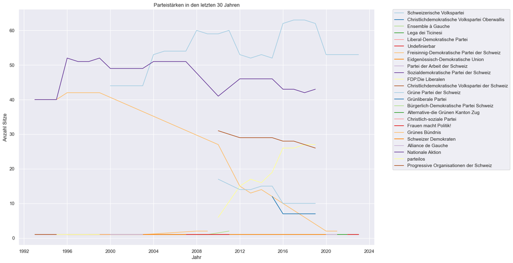

```python
df_plot = list_party_agg[list_party_agg['Jahr'] >= '1993-01-01']
df_plot_nationalrat = df_plot[df_plot['CouncilName'] == 'Nationalrat']
df_plot_nationalrat = df_plot_nationalrat[df_plot_nationalrat['PartyNameReduced'] != 'Andere']
sns.figsize=(15, 10)
sns.lineplot(data=df_plot_nationalrat, x='Jahr', y='Anzahl_Sitze', hue='PartyNameReduced', palette='Paired')
plt.title('Parteistärken in den letzten 30 Jahren')
plt.xlabel('Jahr')
plt.ylabel('Anzahl Sitze')
plt.legend(bbox_to_anchor=(1.05, 1), loc=2, borderaxespad=0.)
plt.show()
```

#### Ständerat

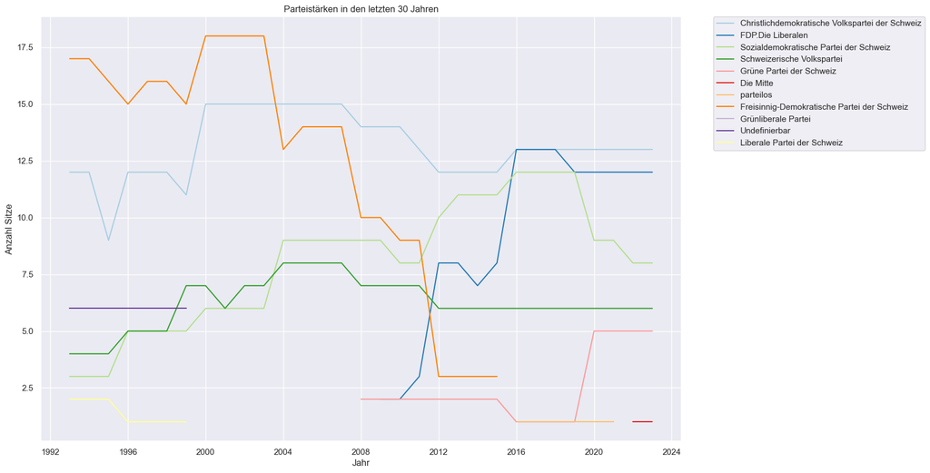

```python
sns.set_theme(style="whitegrid")
sns.set(rc={'figure.figsize':(15, 10)})
df_plot_standerat = df_plot[df_plot['CouncilName'] == 'Ständerat']
df_plot_standerat = df_plot_standerat[df_plot_standerat['PartyNameReduced'] != 'Andere']
sns.figsize=(15, 10)
sns.lineplot(data=df_plot_standerat, x='Jahr', y='Anzahl_Sitze', hue='PartyNameReduced', palette='Paired')
plt.title('Parteistärken in den letzten 30 Jahren')
plt.xlabel('Jahr')
plt.ylabel('Anzahl Sitze')
plt.legend(bbox_to_anchor=(1.05, 1), loc=2, borderaxespad=0.)
plt.show()
```

#### Bundesrat

Hier sollte ein Balkendiagramm verwendet werden, da wenige Informationen vorhanden sind.

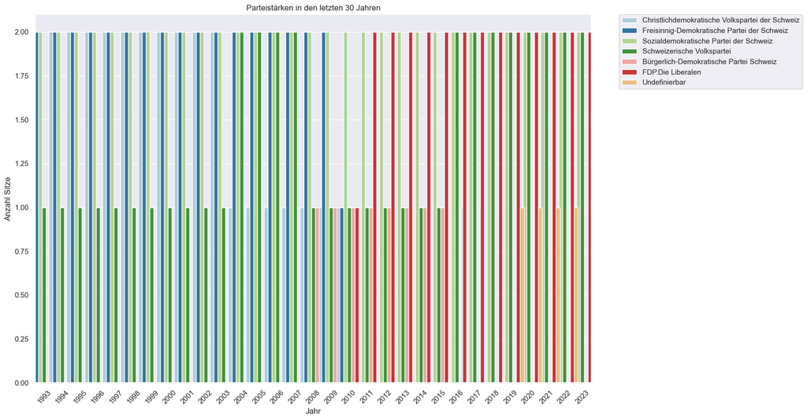

```python
sns.set_theme(style="whitegrid")
sns.set(rc={'figure.figsize':(15, 10)})
df_plot_bundesrat = df_plot[df_plot['CouncilName'] == 'Bundesrat']
df_plot_bundesrat = df_plot_bundesrat[df_plot_bundesrat['PartyNameReduced'] != 'Andere']
df_plot_bundesrat['Jahr'] = df_plot_bundesrat['Jahr'].dt.year
sns.figsize=(15, 20)
sns.barplot(data=df_plot_bundesrat, x='Jahr', y='Anzahl_Sitze', hue='PartyNameReduced', palette='Paired', width=1.5)
plt.title('Parteistärken in den letzten 30 Jahren')
plt.xlabel('Jahr')
plt.ylabel('Anzahl Sitze')
plt.legend(bbox_to_anchor=(1.05, 1), loc=2, borderaxespad=0.)
plt.xticks(rotation=45)
plt.show()
```

#### 2.2.5 Wie war die "Zauberformel" (Parteiverteilung im Bundesrat) und wie gut stimmte diese mit den Parteistärken im Parlament überein?

Es wird eine Liste erstellt mit folgender Struktur: Jahr, Partei, prozentuale Parteistärke in der Bundesversammlung (National- und Ständerat), prozentuale Parteistärke im Bundesrat. Die Liste wird nach Jahr und Parteistärke in der Bundesversammlung sortiert. Für die Visualisierung wird eine geeignete Grafik erstellt, die das Verhältnis der Parteistärke in der Bundesversammlung zur Parteistärke im Bundesrat über die Zeit darstellt.

Für die Zauberformel werden die Sitze im Bundesrat gemäss den vier stärksten Parteien in der Bundesversammlung verteilt. Dabei erhalten die drei stärksten Parteien jeweils zwei Sitze und die viertstärkste Partei einen Sitz. Die Formel für den Bundesrat lautet also 2-2-2-1.

```python
list_magic_formula = list_party_final.copy()
list_magic_formula['CouncilName'] = list_magic_formula.apply(lambda x: 'Bundesversammlung' if x['CouncilName'] == 'Nationalrat' or x['CouncilName'] == 'Ständerat' else 'Bundesrat', axis=1).reset_index(drop=True)
list_magic_formula_bv = list_magic_formula[list_magic_formula['CouncilName'] == 'Bundesversammlung'].reset_index(drop=True)
list_magic_formula_bv['PartyNameReduced'] = list_magic_formula_bv.groupby(['CouncilName', 'Jahr'], observed = True)['PartyName'].transform(
    lambda x: x.where(x.isin(x.value_counts().nlargest(4).index), 'Andere'))
list_magic_formula_bv = list_magic_formula_bv[list_magic_formula_bv['PartyNameReduced'] != 'Andere']
list_magic_formula_bv = list_magic_formula_bv.groupby(['CouncilName', 'Jahr', 'PartyNameReduced'], observed = True).agg({'Anzahl_Sitze': 'sum'}).reset_index()
list_magic_formula_bv
```

|  | CouncilName | Jahr | PartyNameReduced | Anzahl_Sitze |
| --- | --- | --- | --- | --- |
| 0 | Bundesversammlung | 1849-01-01 | Freisinnig-Demokratische Partei der Schweiz | 74.0 |
| 1 | Bundesversammlung | 1849-01-01 | Konservative | 18.0 |
| 2 | Bundesversammlung | 1849-01-01 | Liberale | 48.0 |
| 3 | Bundesversammlung | 1849-01-01 | Reformiert Konservative | 4.0 |
| 4 | Bundesversammlung | 1850-01-01 | Freisinnig-Demokratische Partei der Schweiz | 75.0 |
| ... | ... | ... | ... | ... |
| 695 | Bundesversammlung | 2022-01-01 | Schweizerische Volkspartei | 59.0 |
| 696 | Bundesversammlung | 2023-01-01 | Christlichdemokratische Volkspartei der Schweiz | 37.0 |
| 697 | Bundesversammlung | 2023-01-01 | FDP.Die Liberalen | 37.0 |
| 698 | Bundesversammlung | 2023-01-01 | Grüne Partei der Schweiz | 31.0 |
| 699 | Bundesversammlung | 2023-01-01 | Schweizerische Volkspartei | 59.0 |

700 rows × 4 columns

Für die Berechnung der prozentualen Parteistärke wird eine neue Spalte erstellt.

```python
list_magic_formula_bv['Percent'] = list_magic_formula_bv.groupby(['CouncilName', 'Jahr'], observed = True)['Anzahl_Sitze'].transform(lambda x: x / x.sum() * 100)
list_magic_formula_bv['Percent'] = list_magic_formula_bv['Percent'].round(2)
list_magic_formula_bv = list_magic_formula_bv.rename(columns={'PartyNameReduced': 'PartyName'})
list_magic_formula_bv
```

|  | CouncilName | Jahr | PartyName | Anzahl_Sitze | Percent |
| --- | --- | --- | --- | --- | --- |
| 0 | Bundesversammlung | 1849-01-01 | Freisinnig-Demokratische Partei der Schweiz | 74.0 | 51.39 |
| 1 | Bundesversammlung | 1849-01-01 | Konservative | 18.0 | 12.50 |
| 2 | Bundesversammlung | 1849-01-01 | Liberale | 48.0 | 33.33 |
| 3 | Bundesversammlung | 1849-01-01 | Reformiert Konservative | 4.0 | 2.78 |
| 4 | Bundesversammlung | 1850-01-01 | Freisinnig-Demokratische Partei der Schweiz | 75.0 | 50.00 |
| ... | ... | ... | ... | ... | ... |
| 695 | Bundesversammlung | 2022-01-01 | Schweizerische Volkspartei | 59.0 | 35.98 |
| 696 | Bundesversammlung | 2023-01-01 | Christlichdemokratische Volkspartei der Schweiz | 37.0 | 22.56 |
| 697 | Bundesversammlung | 2023-01-01 | FDP.Die Liberalen | 37.0 | 22.56 |
| 698 | Bundesversammlung | 2023-01-01 | Grüne Partei der Schweiz | 31.0 | 18.90 |
| 699 | Bundesversammlung | 2023-01-01 | Schweizerische Volkspartei | 59.0 | 35.98 |

700 rows × 5 columns

Parteistärke Bundesrat. Vorgehen ist dasselbe wie bei der Bundesversammlung.

```python
list_magic_formula_br = list_magic_formula[list_magic_formula['CouncilName'] == 'Bundesrat'].reset_index(drop=True)
list_magic_formula_br['Percent'] = list_magic_formula_br.groupby(['CouncilName', 'Jahr'], observed = True)['Anzahl_Sitze'].transform(lambda x: x / x.sum() * 100)
list_magic_formula_br['Percent'] = list_magic_formula_br['Percent'].round(2)
list_magic_formula_br
```

|  | CouncilName | Jahr | PartyName | Anzahl_Sitze | Percent |
| --- | --- | --- | --- | --- | --- |
| 0 | Bundesrat | 1849-01-01 | Freisinnig-Demokratische Partei der Schweiz | 5.0 | 71.43 |
| 1 | Bundesrat | 1849-01-01 | Liberale | 2.0 | 28.57 |
| 2 | Bundesrat | 1850-01-01 | Freisinnig-Demokratische Partei der Schweiz | 5.0 | 71.43 |
| 3 | Bundesrat | 1850-01-01 | Liberale | 2.0 | 28.57 |
| 4 | Bundesrat | 1851-01-01 | Freisinnig-Demokratische Partei der Schweiz | 5.0 | 71.43 |
| ... | ... | ... | ... | ... | ... |
| 591 | Bundesrat | 2022-01-01 | Undefinierbar | 1.0 | 14.29 |
| 592 | Bundesrat | 2023-01-01 | Sozialdemokratische Partei der Schweiz | 2.0 | 28.57 |
| 593 | Bundesrat | 2023-01-01 | FDP.Die Liberalen | 2.0 | 28.57 |
| 594 | Bundesrat | 2023-01-01 | Schweizerische Volkspartei | 2.0 | 28.57 |
| 595 | Bundesrat | 2023-01-01 | Undefinierbar | 1.0 | 14.29 |

596 rows × 5 columns

Die beiden Listen werden nun zusammengeführt, die Spalte 'Anzahl_Sitze' wird gelöscht und in der Spalte Jahr wird nur noch das Jahr angezeigt.

```python
list_magic_formula_concat = pd.concat([list_magic_formula_bv, list_magic_formula_br])
list_magic_formula_concat = list_magic_formula_concat.drop(columns=['Anzahl_Sitze'])
list_magic_formula_concat['Jahr'] = list_magic_formula_concat['Jahr'].dt.year
list_magic_formula_concat= list_magic_formula_concat.rename(columns={'PartyName': 'Partei', 'Percent': 'Prozent', 'CouncilName': 'Rat'})
list_magic_formula_concat
```

|  | Rat | Jahr | Partei | Prozent |
| --- | --- | --- | --- | --- |
| 0 | Bundesversammlung | 1849 | Freisinnig-Demokratische Partei der Schweiz | 51.39 |
| 1 | Bundesversammlung | 1849 | Konservative | 12.50 |
| 2 | Bundesversammlung | 1849 | Liberale | 33.33 |
| 3 | Bundesversammlung | 1849 | Reformiert Konservative | 2.78 |
| 4 | Bundesversammlung | 1850 | Freisinnig-Demokratische Partei der Schweiz | 50.00 |
| ... | ... | ... | ... | ... |
| 591 | Bundesrat | 2022 | Undefinierbar | 14.29 |
| 592 | Bundesrat | 2023 | Sozialdemokratische Partei der Schweiz | 28.57 |
| 593 | Bundesrat | 2023 | FDP.Die Liberalen | 28.57 |
| 594 | Bundesrat | 2023 | Schweizerische Volkspartei | 28.57 |
| 595 | Bundesrat | 2023 | Undefinierbar | 14.29 |

1296 rows × 4 columns

Nun werden die Prozente der Parteistärke in der Bundesversammlung und im Bundesrat pivotiert.

```python
list_magic_formula_pivot = pd.pivot_table(list_magic_formula_concat, values="Prozent", index=["Jahr", "Partei"], columns=["Rat"]).fillna(0)
list_magic_formula_pivot = list_magic_formula_pivot.sort_values(by=['Jahr', 'Bundesversammlung'], ascending=[True, False]).reset_index()
list_magic_formula_pivot
```

| Rat | Jahr | Partei | Bundesrat | Bundesversammlung |
| --- | --- | --- | --- | --- |
| 0 | 1849 | Freisinnig-Demokratische Partei der Schweiz | 71.43 | 51.39 |
| 1 | 1849 | Liberale | 28.57 | 33.33 |
| 2 | 1849 | Konservative | 0.00 | 12.50 |
| 3 | 1849 | Reformiert Konservative | 0.00 | 2.78 |
| 4 | 1850 | Freisinnig-Demokratische Partei der Schweiz | 71.43 | 50.00 |
| ... | ... | ... | ... | ... |
| 776 | 2023 | Christlichdemokratische Volkspartei der Schweiz | 0.00 | 22.56 |
| 777 | 2023 | FDP.Die Liberalen | 28.57 | 22.56 |
| 778 | 2023 | Grüne Partei der Schweiz | 0.00 | 18.90 |
| 779 | 2023 | Sozialdemokratische Partei der Schweiz | 28.57 | 0.00 |
| 780 | 2023 | Undefinierbar | 14.29 | 0.00 |

781 rows × 4 columns

#### Visualisierung

Auch hier sind wieder sehr viele Daten vorhanden wenn der gesamte Zeitraum betrachtet wird. Darum schauen wir wiederum nur die letzten 30 Jahre an.

```python
df_plot_magic = list_magic_formula_pivot[list_magic_formula_pivot['Jahr'] >= 1993].reset_index(drop=True)
```

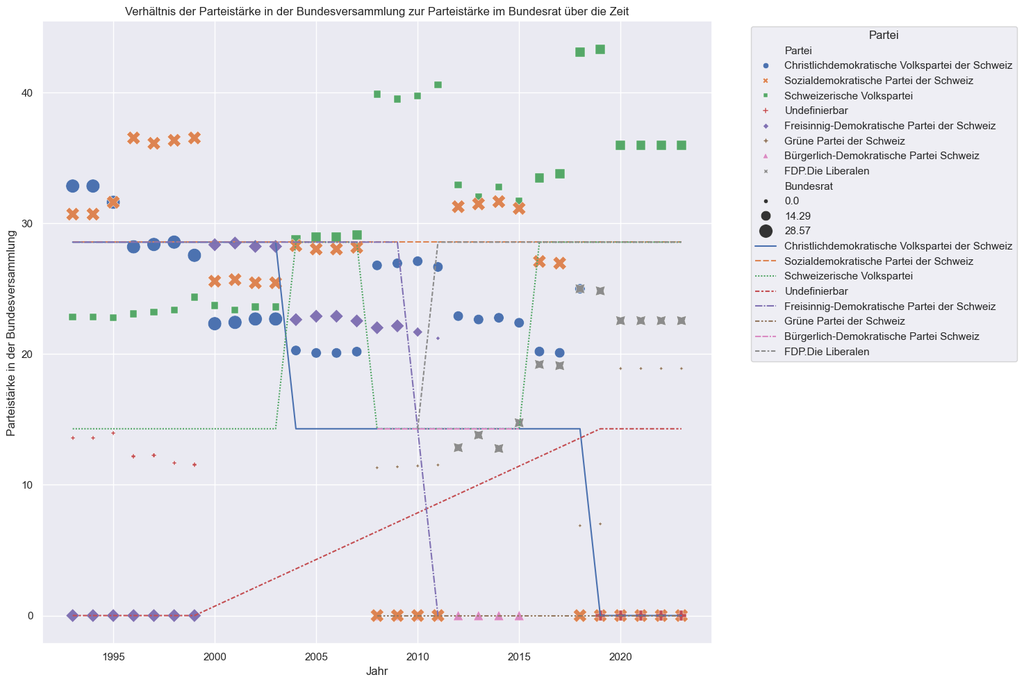

```python
sns.set_theme(style="whitegrid")
sns.set(rc={'figure.figsize':(15, 10)})
sns.scatterplot(data=df_plot_magic, x="Jahr", y="Bundesversammlung", hue="Partei", style="Partei", size="Bundesrat", sizes=(20, 200))
sns.lineplot(data=df_plot_magic, x="Jahr", y="Bundesrat", hue="Partei", style="Partei")
plt.title('Verhältnis der Parteistärke in der Bundesversammlung zur Parteistärke im Bundesrat über die Zeit')
plt.xlabel('Jahr')
plt.ylabel('Parteistärke in der Bundesversammlung')
plt.legend(bbox_to_anchor=(1.05, 1), loc='upper left', title="Partei")
plt.grid(True)
plt.tight_layout()
plt.show()
```

#### 2.2.6 Wie hat sich die Frauenquote über die Zeit verändert?

Es wird eine Liste erstellt mit folgender Struktur: Jahr, Rat, Anzahl Mitglieder, Anzahl Frauen, Anzahl Männer, Frauenquote

```python
list_f_quote = df_final[['CouncilName', 'Eintritt', 'Austritt', 'GenderAsString']].copy()
list_f_quote = list_f_quote[list_f_quote['CouncilName'] != 'Bundeskanzler']
list_f_quote['Jahr'] = list_f_quote.apply(lambda x: pd.date_range(start=x['Eintritt'], end=x['Austritt'], freq='YS'), axis=1)
list_f_quote = list_f_quote.explode('Jahr')
list_f_quote
```

|  | CouncilName | Eintritt | Austritt | GenderAsString | Jahr |
| --- | --- | --- | --- | --- | --- |
| 0 | Ständerat | 1849-12-01 | 1851-07-01 | m | 1850-01-01 |
| 0 | Ständerat | 1849-12-01 | 1851-07-01 | m | 1851-01-01 |
| 1 | Nationalrat | 1928-12-03 | 1935-12-01 | m | 1929-01-01 |
| 1 | Nationalrat | 1928-12-03 | 1935-12-01 | m | 1930-01-01 |
| 1 | Nationalrat | 1928-12-03 | 1935-12-01 | m | 1931-01-01 |
| ... | ... | ... | ... | ... | ... |
| 6716 | Nationalrat | 1866-12-03 | 1893-12-03 | m | 1889-01-01 |
| 6716 | Nationalrat | 1866-12-03 | 1893-12-03 | m | 1890-01-01 |
| 6716 | Nationalrat | 1866-12-03 | 1893-12-03 | m | 1891-01-01 |
| 6716 | Nationalrat | 1866-12-03 | 1893-12-03 | m | 1892-01-01 |
| 6716 | Nationalrat | 1866-12-03 | 1893-12-03 | m | 1893-01-01 |

39478 rows × 5 columns

Die Anzahl Mitglieder pro Jahr, Rat werden gezählt und in der Spalte 'Anzahl_Mitglieder' gespeichert.

```python
list_f_quote['Anzahl_Mitglieder'] = list_f_quote.groupby(['CouncilName', 'Jahr'], observed = True)['CouncilName'].transform('count')
list_f_quote
```

|  | CouncilName | Eintritt | Austritt | GenderAsString | Jahr | Anzahl_Mitglieder |
| --- | --- | --- | --- | --- | --- | --- |
| 0 | Ständerat | 1849-12-01 | 1851-07-01 | m | 1850-01-01 | 42.0 |
| 0 | Ständerat | 1849-12-01 | 1851-07-01 | m | 1851-01-01 | 43.0 |
| 1 | Nationalrat | 1928-12-03 | 1935-12-01 | m | 1929-01-01 | 198.0 |
| 1 | Nationalrat | 1928-12-03 | 1935-12-01 | m | 1930-01-01 | 198.0 |
| 1 | Nationalrat | 1928-12-03 | 1935-12-01 | m | 1931-01-01 | 195.0 |
| ... | ... | ... | ... | ... | ... | ... |
| 6716 | Nationalrat | 1866-12-03 | 1893-12-03 | m | 1889-01-01 | 143.0 |
| 6716 | Nationalrat | 1866-12-03 | 1893-12-03 | m | 1890-01-01 | 143.0 |
| 6716 | Nationalrat | 1866-12-03 | 1893-12-03 | m | 1891-01-01 | 144.0 |
| 6716 | Nationalrat | 1866-12-03 | 1893-12-03 | m | 1892-01-01 | 146.0 |
| 6716 | Nationalrat | 1866-12-03 | 1893-12-03 | m | 1893-01-01 | 144.0 |

39478 rows × 6 columns

Nun können die Anzahl Mitglieder pro Jahr, Rat und Geschlecht gezählt werden. Die Werte werden in der Spalte 'Anzahl_Geschlecht' gespeichert.

```python
list_f_quote['Anzahl_Geschlecht'] = list_f_quote.groupby(['CouncilName', 'Jahr', 'GenderAsString'], observed = True)['GenderAsString'].transform('count')
list_f_quote['Jahr'] = list_f_quote['Jahr'].dt.year
list_f_quote
```

|  | CouncilName | Eintritt | Austritt | GenderAsString | Jahr | Anzahl_Mitglieder | Anzahl_Geschlecht |
| --- | --- | --- | --- | --- | --- | --- | --- |
| 0 | Ständerat | 1849-12-01 | 1851-07-01 | m | 1850.0 | 42.0 | 42.0 |
| 0 | Ständerat | 1849-12-01 | 1851-07-01 | m | 1851.0 | 43.0 | 43.0 |
| 1 | Nationalrat | 1928-12-03 | 1935-12-01 | m | 1929.0 | 198.0 | 198.0 |
| 1 | Nationalrat | 1928-12-03 | 1935-12-01 | m | 1930.0 | 198.0 | 198.0 |
| 1 | Nationalrat | 1928-12-03 | 1935-12-01 | m | 1931.0 | 195.0 | 195.0 |
| ... | ... | ... | ... | ... | ... | ... | ... |
| 6716 | Nationalrat | 1866-12-03 | 1893-12-03 | m | 1889.0 | 143.0 | 143.0 |
| 6716 | Nationalrat | 1866-12-03 | 1893-12-03 | m | 1890.0 | 143.0 | 143.0 |
| 6716 | Nationalrat | 1866-12-03 | 1893-12-03 | m | 1891.0 | 144.0 | 144.0 |
| 6716 | Nationalrat | 1866-12-03 | 1893-12-03 | m | 1892.0 | 146.0 | 146.0 |
| 6716 | Nationalrat | 1866-12-03 | 1893-12-03 | m | 1893.0 | 144.0 | 144.0 |

39478 rows × 7 columns

Nun müssen noch die Duplikate, welche durch die Aggregation entstanden sind, entfernt werden.

```python
list_f_quote_final = list_f_quote.drop_duplicates(subset=['CouncilName', 'Jahr', 'GenderAsString', 'Anzahl_Geschlecht', 'Anzahl_Mitglieder']).reset_index(drop=True)
list_f_quote_final
```

|  | CouncilName | Eintritt | Austritt | GenderAsString | Jahr | Anzahl_Mitglieder | Anzahl_Geschlecht |
| --- | --- | --- | --- | --- | --- | --- | --- |
| 0 | Ständerat | 1849-12-01 | 1851-07-01 | m | 1850.0 | 42.0 | 42.0 |
| 1 | Ständerat | 1849-12-01 | 1851-07-01 | m | 1851.0 | 43.0 | 43.0 |
| 2 | Nationalrat | 1928-12-03 | 1935-12-01 | m | 1929.0 | 198.0 | 198.0 |
| 3 | Nationalrat | 1928-12-03 | 1935-12-01 | m | 1930.0 | 198.0 | 198.0 |
| 4 | Nationalrat | 1928-12-03 | 1935-12-01 | m | 1931.0 | 195.0 | 195.0 |
| ... | ... | ... | ... | ... | ... | ... | ... |
| 660 | Bundesrat | 2006-08-01 | 2018-12-31 | f | 2016.0 | 7.0 | 2.0 |
| 661 | Bundesrat | 2006-08-01 | 2018-12-31 | f | 2017.0 | 7.0 | 2.0 |
| 662 | Bundesrat | 2006-08-01 | 2018-12-31 | f | 2018.0 | 7.0 | 2.0 |
| 663 | Ständerat | 1978-02-27 | 1983-11-27 | f | 1979.0 | 44.0 | 1.0 |
| 664 | Ständerat | 1995-01-23 | 1995-12-03 | f | NaN | NaN | NaN |

665 rows × 7 columns

Für die geforderte Liste wird wieder pivotiert.

```python
list_f_quote_pivot = pd.pivot_table(list_f_quote_final, values=["Anzahl_Geschlecht"], index=["Jahr", "CouncilName", "Anzahl_Mitglieder"], columns=["GenderAsString"]).fillna(0)
list_f_quote_pivot = list_f_quote_pivot.reset_index()
list_f_quote_pivot.columns = ['Jahr', 'Rat', 'Anzahl_Mitglieder', 'Anzahl_Frauen', 'Anzahl_Männer']
list_f_quote_pivot
```

|  | Jahr | Rat | Anzahl_Mitglieder | Anzahl_Frauen | Anzahl_Männer |
| --- | --- | --- | --- | --- | --- |
| 0 | 1849.0 | Bundesrat | 7.0 | 0.0 | 7.0 |
| 1 | 1849.0 | Nationalrat | 108.0 | 0.0 | 108.0 |
| 2 | 1849.0 | Ständerat | 39.0 | 0.0 | 39.0 |
| 3 | 1850.0 | Bundesrat | 7.0 | 0.0 | 7.0 |
| 4 | 1850.0 | Nationalrat | 111.0 | 0.0 | 111.0 |
| ... | ... | ... | ... | ... | ... |
| 520 | 2022.0 | Nationalrat | 200.0 | 85.0 | 115.0 |
| 521 | 2022.0 | Ständerat | 46.0 | 13.0 | 33.0 |
| 522 | 2023.0 | Bundesrat | 7.0 | 3.0 | 4.0 |
| 523 | 2023.0 | Nationalrat | 200.0 | 85.0 | 115.0 |
| 524 | 2023.0 | Ständerat | 46.0 | 13.0 | 33.0 |

525 rows × 5 columns

#### Frauenquote berechnen

Die Frauenquote wird in einer neuen Spalte berechnet.

```python
list_f_quote_pivot['Frauenquote'] = list_f_quote_pivot['Anzahl_Frauen'] / list_f_quote_pivot['Anzahl_Mitglieder'] * 100
list_f_quote_pivot['Frauenquote'] = list_f_quote_pivot['Frauenquote'].round(2)
list_f_quote_pivot
```

|  | Jahr | Rat | Anzahl_Mitglieder | Anzahl_Frauen | Anzahl_Männer | Frauenquote |
| --- | --- | --- | --- | --- | --- | --- |
| 0 | 1849.0 | Bundesrat | 7.0 | 0.0 | 7.0 | 0.00 |
| 1 | 1849.0 | Nationalrat | 108.0 | 0.0 | 108.0 | 0.00 |
| 2 | 1849.0 | Ständerat | 39.0 | 0.0 | 39.0 | 0.00 |
| 3 | 1850.0 | Bundesrat | 7.0 | 0.0 | 7.0 | 0.00 |
| 4 | 1850.0 | Nationalrat | 111.0 | 0.0 | 111.0 | 0.00 |
| ... | ... | ... | ... | ... | ... | ... |
| 520 | 2022.0 | Nationalrat | 200.0 | 85.0 | 115.0 | 42.50 |
| 521 | 2022.0 | Ständerat | 46.0 | 13.0 | 33.0 | 28.26 |
| 522 | 2023.0 | Bundesrat | 7.0 | 3.0 | 4.0 | 42.86 |
| 523 | 2023.0 | Nationalrat | 200.0 | 85.0 | 115.0 | 42.50 |
| 524 | 2023.0 | Ständerat | 46.0 | 13.0 | 33.0 | 28.26 |

525 rows × 6 columns

#### Visualisierung

Da wir hier nur wenige Variablen haben, die wir miteinander vergleichen wollen, können wir den gesamten Datensatz verwenden.

[figure not shown]

```python
sns.set_theme(style="whitegrid")
sns.set(rc={'figure.figsize':(15, 10)})
sns.lineplot(data=list_f_quote_pivot, x='Jahr', y='Anzahl_Mitglieder', hue='Rat', palette='bright', style='Rat', linewidth=2.5)
sns.lineplot(data=list_f_quote_pivot, x='Jahr', y='Anzahl_Frauen', hue='Rat', palette='bright', linewidth=2.5)
plt.title('Entwicklung Frauenquote in den Räten über die Zeit')
plt.xlabel('Jahr')
plt.ylabel('Frauenquote')
legend_labels = ['Bundesrat total', 'Bundesrat Frauenquote', 'Nationalrat total', 'Nationalrat Frauenquote', 'Ständerat total', 'Ständerat Frauenquote']
plt.legend(labels=legend_labels)
plt.show()
```